# Import data

```python
import pandas as pd

training_set = pd.read_csv('UNSW_NB15_training-set.csv')
testing_set = pd.read_csv('UNSW_NB15_test-set.csv')
```

```python
training_set
```

|  | id | dur | proto | service | state | spkts | dpkts | sbytes | dbytes | rate | ... | ct_dst_sport_ltm | ct_dst_src_ltm | is_ftp_login | ct_ftp_cmd | ct_flw_http_mthd | ct_src_ltm | ct_srv_dst | is_sm_ips_ports | attack_cat | label |
| --- | --- | --- | --- | --- | --- | --- | --- | --- | --- | --- | --- | --- | --- | --- | --- | --- | --- | --- | --- | --- | --- |
| 0 | 1 | 0.121478 | tcp | - | FIN | 6 | 4 | 258 | 172 | 74.087490 | ... | 1 | 1 | 0 | 0 | 0 | 1 | 1 | 0 | Normal | 0 |
| 1 | 2 | 0.649902 | tcp | - | FIN | 14 | 38 | 734 | 42014 | 78.473372 | ... | 1 | 2 | 0 | 0 | 0 | 1 | 6 | 0 | Normal | 0 |
| 2 | 3 | 1.623129 | tcp | - | FIN | 8 | 16 | 364 | 13186 | 14.170161 | ... | 1 | 3 | 0 | 0 | 0 | 2 | 6 | 0 | Normal | 0 |
| 3 | 4 | 1.681642 | tcp | ftp | FIN | 12 | 12 | 628 | 770 | 13.677108 | ... | 1 | 3 | 1 | 1 | 0 | 2 | 1 | 0 | Normal | 0 |
| 4 | 5 | 0.449454 | tcp | - | FIN | 10 | 6 | 534 | 268 | 33.373826 | ... | 1 | 40 | 0 | 0 | 0 | 2 | 39 | 0 | Normal | 0 |
| ... | ... | ... | ... | ... | ... | ... | ... | ... | ... | ... | ... | ... | ... | ... | ... | ... | ... | ... | ... | ... | ... |
| 175336 | 175337 | 0.000009 | udp | dns | INT | 2 | 0 | 114 | 0 | 111111.107200 | ... | 13 | 24 | 0 | 0 | 0 | 24 | 24 | 0 | Generic | 1 |
| 175337 | 175338 | 0.505762 | tcp | - | FIN | 10 | 8 | 620 | 354 | 33.612649 | ... | 1 | 2 | 0 | 0 | 0 | 1 | 1 | 0 | Shellcode | 1 |
| 175338 | 175339 | 0.000009 | udp | dns | INT | 2 | 0 | 114 | 0 | 111111.107200 | ... | 3 | 13 | 0 | 0 | 0 | 3 | 12 | 0 | Generic | 1 |
| 175339 | 175340 | 0.000009 | udp | dns | INT | 2 | 0 | 114 | 0 | 111111.107200 | ... | 14 | 30 | 0 | 0 | 0 | 30 | 30 | 0 | Generic | 1 |
| 175340 | 175341 | 0.000009 | udp | dns | INT | 2 | 0 | 114 | 0 | 111111.107200 | ... | 16 | 30 | 0 | 0 | 0 | 30 | 30 | 0 | Generic | 1 |

175341 rows × 45 columns

```python
testing_set
```

|  | id | dur | proto | service | state | spkts | dpkts | sbytes | dbytes | rate | ... | ct_dst_sport_ltm | ct_dst_src_ltm | is_ftp_login | ct_ftp_cmd | ct_flw_http_mthd | ct_src_ltm | ct_srv_dst | is_sm_ips_ports | attack_cat | label |
| --- | --- | --- | --- | --- | --- | --- | --- | --- | --- | --- | --- | --- | --- | --- | --- | --- | --- | --- | --- | --- | --- |
| 0 | 1 | 0.000011 | udp | - | INT | 2 | 0 | 496 | 0 | 90909.090200 | ... | 1 | 2 | 0 | 0 | 0 | 1 | 2 | 0 | Normal | 0 |
| 1 | 2 | 0.000008 | udp | - | INT | 2 | 0 | 1762 | 0 | 125000.000300 | ... | 1 | 2 | 0 | 0 | 0 | 1 | 2 | 0 | Normal | 0 |
| 2 | 3 | 0.000005 | udp | - | INT | 2 | 0 | 1068 | 0 | 200000.005100 | ... | 1 | 3 | 0 | 0 | 0 | 1 | 3 | 0 | Normal | 0 |
| 3 | 4 | 0.000006 | udp | - | INT | 2 | 0 | 900 | 0 | 166666.660800 | ... | 1 | 3 | 0 | 0 | 0 | 2 | 3 | 0 | Normal | 0 |
| 4 | 5 | 0.000010 | udp | - | INT | 2 | 0 | 2126 | 0 | 100000.002500 | ... | 1 | 3 | 0 | 0 | 0 | 2 | 3 | 0 | Normal | 0 |
| ... | ... | ... | ... | ... | ... | ... | ... | ... | ... | ... | ... | ... | ... | ... | ... | ... | ... | ... | ... | ... | ... |
| 82327 | 82328 | 0.000005 | udp | - | INT | 2 | 0 | 104 | 0 | 200000.005100 | ... | 1 | 2 | 0 | 0 | 0 | 2 | 1 | 0 | Normal | 0 |
| 82328 | 82329 | 1.106101 | tcp | - | FIN | 20 | 8 | 18062 | 354 | 24.410067 | ... | 1 | 1 | 0 | 0 | 0 | 3 | 2 | 0 | Normal | 0 |
| 82329 | 82330 | 0.000000 | arp | - | INT | 1 | 0 | 46 | 0 | 0.000000 | ... | 1 | 1 | 0 | 0 | 0 | 1 | 1 | 1 | Normal | 0 |
| 82330 | 82331 | 0.000000 | arp | - | INT | 1 | 0 | 46 | 0 | 0.000000 | ... | 1 | 1 | 0 | 0 | 0 | 1 | 1 | 1 | Normal | 0 |
| 82331 | 82332 | 0.000009 | udp | - | INT | 2 | 0 | 104 | 0 | 111111.107200 | ... | 1 | 1 | 0 | 0 | 0 | 1 | 1 | 0 | Normal | 0 |

82332 rows × 45 columns

```python
if testing_set.columns.equals(training_set.columns):
    print("Both DataFrames have the same feature names.")
else:
    print("Both DataFrames do not have the same feature names.")
```

```
Both DataFrames have the same feature names.
```

```python
testing_set.columns.to_list()
```

```
['id',
 'dur',
 'proto',
 'service',
 'state',
 'spkts',
 'dpkts',
 'sbytes',
 'dbytes',
 'rate',
 'sttl',
 'dttl',
 'sload',
 'dload',
 'sloss',
 'dloss',
 'sinpkt',
 'dinpkt',
 'sjit',
 'djit',
 'swin',
 'stcpb',
 'dtcpb',
 'dwin',
 'tcprtt',
 'synack',
 'ackdat',
 'smean',
 'dmean',
 'trans_depth',
 'response_body_len',
 'ct_srv_src',
 'ct_state_ttl',
 'ct_dst_ltm',
 'ct_src_dport_ltm',
 'ct_dst_sport_ltm',
 'ct_dst_src_ltm',
 'is_ftp_login',
 'ct_ftp_cmd',
 'ct_flw_http_mthd',
 'ct_src_ltm',
 'ct_srv_dst',
 'is_sm_ips_ports',
 'attack_cat',
 'label']
```

# Remove all the records with categorical values that only appear in training or test data.

Categorical features: proto, state, service, is_sm_ips_ports, is_ftp_login

```python
testing_unique = testing_set[['proto','state', 'service', 'is_sm_ips_ports', 'is_ftp_login']].nunique()
testing_unique
```

```
proto              131
state                7
service             13
is_sm_ips_ports      2
is_ftp_login         3
dtype: int64
```

```python
training_unique = training_set[['proto','state', 'service', 'is_sm_ips_ports', 'is_ftp_login']].nunique()
training_unique
```

```
proto              133
state                9
service             13
is_sm_ips_ports      2
is_ftp_login         4
dtype: int64
```

See which categorical features has same unique values in the categorical features

```python
df1 = testing_set[['proto','state', 'service', 'is_sm_ips_ports', 'is_ftp_login']].copy()
df2 = training_set[['proto','state', 'service', 'is_sm_ips_ports', 'is_ftp_login']].copy()

# Iterate through columns
for column in df1.columns:
    unique_values_df1 = df1[column].unique()
    unique_values_df2 = df2[column].unique()

    if set(unique_values_df1) == set(unique_values_df2):
        print(f"Column {column} is Same")
    else:
        print(f"Column {column} is Not Same")
```

```
Column proto is Not Same
Column state is Not Same
Column service is Same
Column is_sm_ips_ports is Same
Column is_ftp_login is Not Same
```

Find the values where a unique value does not occur in training/testing dataset

```python
# df1 = testing dataset
# df2 = training dataset

# Columns to compare
columns_to_compare = ['proto','state','is_ftp_login']

# Loop through the specified columns
for col in columns_to_compare:

    unique_values_df1 = set(df1[col].unique())
    unique_values_df2 = set(df2[col].unique())

    unique_values_not_in_df2 = unique_values_df1 - unique_values_df2
    unique_values_not_in_df1 = unique_values_df2 - unique_values_df1

    if (unique_values_not_in_df1 != set()):
        print(f"Column '{col}' has values {unique_values_not_in_df1} not in Testing dataset")
    if (unique_values_not_in_df2 != set()):
        print(f"Column '{col}' has values {unique_values_not_in_df2} not in Training dataset")
```

```
Column 'proto' has values {'rtp', 'icmp'} not in Testing dataset
Column 'state' has values {'URN', 'ECO', 'no', 'PAR'} not in Testing dataset
Column 'state' has values {'ACC', 'CLO'} not in Training dataset
Column 'is_ftp_login' has values {4} not in Testing dataset
```

Remove the rows where each values occurs.

```python
clean_testing_set = testing_set.copy()
clean_training_set = training_set.copy()

def drop_rows_using_values(df, values, col):
    # Define the specific values you want to drop
    values_to_drop = values

    # Drop rows with any of the specific values in column
    df = df[~df[col].isin(values_to_drop)]

    return df

clean_training_set = drop_rows_using_values(clean_training_set, ['icmp', 'rtp'], 'proto')
clean_training_set = drop_rows_using_values(clean_training_set, ['PAR', 'no', 'URN', 'ECO'], 'state')
clean_training_set = drop_rows_using_values(clean_training_set, [4], 'is_ftp_login')
clean_testing_set = drop_rows_using_values(clean_testing_set, ['ACC', 'CLO'], 'state')
```

Check if training/testing categorical features has same unique values

```python
df1 = clean_testing_set[['proto','state', 'service', 'is_sm_ips_ports', 'is_ftp_login']].copy()
df2 = clean_training_set[['proto','state', 'service', 'is_sm_ips_ports', 'is_ftp_login']].copy()

# Iterate through columns
for column in df1.columns:
    unique_values_df1 = df1[column].unique()
    unique_values_df2 = df2[column].unique()

    if set(unique_values_df1) == set(unique_values_df2):
        print(f"Column {column} is Same")
    else:
        print(f"Column {column} is Not Same")
```

```
Column proto is Same
Column state is Same
Column service is Same
Column is_sm_ips_ports is Same
Column is_ftp_login is Same
```

# Drop any rows with missing values.

### Drop columns that will not be used for training/testing

- Will not use 'id'
- 'attack_cat' will be used as output for extra features section

```python
training = clean_training_set.copy()
testing = clean_testing_set.copy()

training = training.dropna()
testing = testing.dropna()

training.drop('id', axis=1, inplace=True)
testing.drop('id', axis=1, inplace=True)
```

# Encode categorical features and normalize numeric features.

#### Helpful Functions for Tensorflow (little gems)

The following functions will be used with TensorFlow to help preprocess the data. They allow you to build the feature vector for a neural network.

(1) Encoding data:

- **encode_text_dummy** - Encode text fields as numeric, such as the iris species as a single field for each class. Three classes would become "0,0,1" "0,1,0" and "1,0,0". **Encode non-target features this way**. **(one hot encoding)**
- **encode_text_index** - Encode text fields to numeric, such as the iris species as a single numeric field as "0" "1" and "2". **Encode the target field for a classification this way**. **(label encoding)**

(2) Normalizing data:

- **encode_numeric_zscore** - Encode numeric values as a z-score. Neural networks deal well with "normalized" fields only.
- **encode_numeric_range** - Encode a column to a range between the given normalized_low and normalized_high.

(3) Dealing with missing data:

- **missing_median** - Fill all missing values with the median value.

(4) Removing outliers:

- **remove_outliers** - Remove outliers in a certain column with a value beyond X times SD

(5) Creating the **feature vector** and **target vector** that *** Tensorflow needs**. ***Notice that Tensorflow only takes Numpy array as input**

- **to_xy** - If all fields are numeric, this function can ***create X (feature matrix) and Y (response vector) *** in a format TensorFlow needs.

```python
from collections.abc import Sequence
from sklearn import preprocessing
import matplotlib.pyplot as plt
import numpy as np
import pandas as pd
import shutil
import os


# Encode text values to dummy variables(i.e. [1,0,0],[0,1,0],[0,0,1] for red,green,blue)
def encode_text_dummy(df, name):
    dummies = pd.get_dummies(df[name])
    for x in dummies.columns:
        dummy_name = "{}-{}".format(name, x)
        df[dummy_name] = dummies[x]
    df.drop(name, axis=1, inplace=True)


# Encode text values to indexes(i.e. [1],[2],[3] for red,green,blue).
def encode_text_index(df, name):
    le = preprocessing.LabelEncoder()
    df[name] = le.fit_transform(df[name])
    return le.classes_


# Encode a numeric column as zscores
def encode_numeric_zscore(df, name, mean=None, sd=None):
    if mean is None:
        mean = df[name].mean()

    if sd is None:
        sd = df[name].std()

    df[name] = (df[name] - mean) / sd


# Convert all missing values in the specified column to the median
def missing_median(df, name):
    med = df[name].median()
    df[name] = df[name].fillna(med)


# Convert all missing values in the specified column to the default
def missing_default(df, name, default_value):
    df[name] = df[name].fillna(default_value)


# Convert a Pandas dataframe to the x,y inputs that TensorFlow needs
def to_xy(df, target):
    result = []
    for x in df.columns:
        if x != target:
            result.append(x)
    # find out the type of the target column.
    target_type = df[target].dtypes
    target_type = target_type[0] if isinstance(target_type, Sequence) else target_type
    # Encode to int for classification, float otherwise. TensorFlow likes 32 bits.
    if target_type in (np.int64, np.int32):
        # Classification
        dummies = pd.get_dummies(df[target])
        return df[result].values.astype(np.float32), dummies.values.astype(np.float32)
    else:
        # Regression
        return df[result].values.astype(np.float32), df[target].values.astype(np.float32)

# Nicely formatted time string
def hms_string(sec_elapsed):
    h = int(sec_elapsed / (60 * 60))
    m = int((sec_elapsed % (60 * 60)) / 60)
    s = sec_elapsed % 60
    return "{}:{:>02}:{:>05.2f}".format(h, m, s)


# Regression chart.
def chart_regression(pred,y,sort=True):
    t = pd.DataFrame({'pred' : pred, 'y' : y.flatten()})
    if sort:
        t.sort_values(by=['y'],inplace=True)
    a = plt.plot(t['y'].tolist(),label='expected')
    b = plt.plot(t['pred'].tolist(),label='prediction')
    plt.ylabel('output')
    plt.legend()
    plt.show()

# Remove all rows where the specified column is +/- sd standard deviations
def remove_outliers(df, name, sd):
    drop_rows = df.index[(np.abs(df[name] - df[name].mean()) >= (sd * df[name].std()))]
    df.drop(drop_rows, axis=0, inplace=True)


# Encode a column to a range between normalized_low and normalized_high.
def encode_numeric_range(df, name, normalized_low=-1, normalized_high=1,
                         data_low=None, data_high=None):
    if data_low is None:
        data_low = min(df[name])
        data_high = max(df[name])

    df[name] = ((df[name] - data_low) / (data_high - data_low)) * (normalized_high - normalized_low) + normalized_low
```

Categorical features: 'proto', 'state', 'service', 'is_sm_ips_ports', 'is_ftp_login'

```python
columns_to_encode = ['proto','state','service','is_sm_ips_ports','is_ftp_login']

for col in columns_to_encode:
    encode_text_dummy(training, col)
    encode_text_dummy(testing, col)
```

Numerica features: 'dur', 'spkts', 'dpkts', 'sbytes', 'dbytes', 'rate', 'sttl', 'dttl', 'sload', 'dload', 'sloss', 'dloss', 'sinpkt', 'dinpkt', 'sjit', 'djit', 'swin', 'stcpb', 'dtcpb', 'dwin', 'tcprtt', 'synack', 'ackdat', 'smean', 'dmean', 'trans_depth', 'response_body_len', 'ct_srv_src', 'ct_state_ttl', 'ct_dst_ltm', 'ct_src_dport_ltm', 'ct_dst_sport_ltm', 'ct_dst_src_ltm', 'ct_ftp_cmd', 'ct_flw_http_mthd', 'ct_src_ltm', 'ct_srv_dst'

```python
columns_to_normalize = ['dur','spkts','dpkts','sbytes','dbytes','rate','sttl','dttl','sload','dload','sloss','dloss',
 'sinpkt','dinpkt','sjit','djit','swin','stcpb','dtcpb','dwin','tcprtt','synack','ackdat','smean','dmean','trans_depth','response_body_len','ct_srv_src',
 'ct_state_ttl','ct_dst_ltm','ct_src_dport_ltm','ct_dst_sport_ltm','ct_dst_src_ltm','ct_ftp_cmd','ct_flw_http_mthd','ct_src_ltm','ct_srv_dst']

for col in columns_to_normalize:
    encode_numeric_zscore(training, col)
    encode_numeric_zscore(testing, col)
```

```python
training
```

|  | dur | spkts | dpkts | sbytes | dbytes | rate | sttl | dttl | sload | dload | ... | service-radius | service-smtp | service-snmp | service-ssh | service-ssl | is_sm_ips_ports-0 | is_sm_ips_ports-1 | is_ftp_login-0 | is_ftp_login-1 | is_ftp_login-2 |
| --- | --- | --- | --- | --- | --- | --- | --- | --- | --- | --- | --- | --- | --- | --- | --- | --- | --- | --- | --- | --- | --- |
| 0 | -0.191029 | -0.104464 | -0.135778 | -0.049138 | -0.102734 | -0.576395 | 0.703685 | 1.578241 | -0.389891 | -0.273726 | ... | 0 | 0 | 0 | 0 | 0 | 1 | 0 | 1 | 0 | 0 |
| 1 | -0.109493 | -0.046027 | 0.172561 | -0.046414 | 0.188508 | -0.576369 | -1.142084 | 1.560142 | -0.389921 | -0.069277 | ... | 0 | 0 | 0 | 0 | 0 | 1 | 0 | 1 | 0 | 0 |
| 2 | 0.040678 | -0.089854 | -0.026953 | -0.048531 | -0.012150 | -0.576757 | -1.142084 | 1.560142 | -0.389958 | -0.252073 | ... | 0 | 0 | 0 | 0 | 0 | 1 | 0 | 1 | 0 | 0 |
| 3 | 0.049706 | -0.060636 | -0.063228 | -0.047021 | -0.098572 | -0.576760 | -1.142084 | 1.560142 | -0.389951 | -0.275847 | ... | 0 | 0 | 0 | 0 | 0 | 1 | 0 | 0 | 1 | 0 |
| 4 | -0.140422 | -0.075245 | -0.117641 | -0.047558 | -0.102066 | -0.576641 | 0.723114 | 1.560142 | -0.389921 | -0.275588 | ... | 0 | 0 | 0 | 0 | 0 | 1 | 0 | 1 | 0 | 0 |
| ... | ... | ... | ... | ... | ... | ... | ... | ... | ... | ... | ... | ... | ... | ... | ... | ... | ... | ... | ... | ... | ... |
| 175336 | -0.209772 | -0.133682 | -0.172053 | -0.049961 | -0.103932 | 0.094946 | 0.723114 | -0.720359 | -0.120987 | -0.277234 | ... | 0 | 0 | 0 | 0 | 0 | 1 | 0 | 1 | 0 | 0 |
| 175337 | -0.131734 | -0.075245 | -0.099503 | -0.047066 | -0.101468 | -0.576640 | 0.723114 | 1.560142 | -0.389919 | -0.275209 | ... | 0 | 0 | 0 | 0 | 0 | 1 | 0 | 1 | 0 | 0 |
| 175338 | -0.209772 | -0.133682 | -0.172053 | -0.049961 | -0.103932 | 0.094946 | 0.723114 | -0.720359 | -0.120987 | -0.277234 | ... | 0 | 0 | 0 | 0 | 0 | 1 | 0 | 1 | 0 | 0 |
| 175339 | -0.209772 | -0.133682 | -0.172053 | -0.049961 | -0.103932 | 0.094946 | 0.723114 | -0.720359 | -0.120987 | -0.277234 | ... | 0 | 0 | 0 | 0 | 0 | 1 | 0 | 1 | 0 | 0 |
| 175340 | -0.209772 | -0.133682 | -0.172053 | -0.049961 | -0.103932 | 0.094946 | 0.723114 | -0.720359 | -0.120987 | -0.277234 | ... | 0 | 0 | 0 | 0 | 0 | 1 | 0 | 1 | 0 | 0 |

175309 rows × 193 columns

```python
testing
```

|  | dur | spkts | dpkts | sbytes | dbytes | rate | sttl | dttl | sload | dload | ... | service-radius | service-smtp | service-snmp | service-ssh | service-ssl | is_sm_ips_ports-0 | is_sm_ips_ports-1 | is_ftp_login-0 | is_ftp_login-1 | is_ftp_login-2 |
| --- | --- | --- | --- | --- | --- | --- | --- | --- | --- | --- | --- | --- | --- | --- | --- | --- | --- | --- | --- | --- | --- |
| 0 | -0.213729 | -0.124458 | -0.151819 | -0.043685 | -0.087371 | 0.057147 | 0.719430 | -0.820360 | 0.643870 | -0.263500 | ... | 0 | 0 | 0 | 0 | 0 | 1 | 0 | 1 | 0 | 0 |
| 1 | -0.213729 | -0.124458 | -0.151819 | -0.036309 | -0.087371 | 0.286524 | 0.719430 | -0.820360 | 4.539181 | -0.263500 | ... | 0 | 0 | 0 | 0 | 0 | 1 | 0 | 1 | 0 | 0 |
| 2 | -0.213730 | -0.124458 | -0.151819 | -0.040352 | -0.087371 | 0.791155 | 0.719430 | -0.820360 | 4.391294 | -0.263500 | ... | 0 | 0 | 0 | 0 | 0 | 1 | 0 | 1 | 0 | 0 |
| 3 | -0.213730 | -0.124458 | -0.151819 | -0.041331 | -0.087371 | 0.566874 | 0.719430 | -0.820360 | 2.976912 | -0.263500 | ... | 0 | 0 | 0 | 0 | 0 | 1 | 0 | 1 | 0 | 0 |
| 4 | -0.213729 | -0.124458 | -0.151819 | -0.034189 | -0.087371 | 0.118314 | 0.719430 | -0.820360 | 4.369055 | -0.263500 | ... | 0 | 0 | 0 | 0 | 0 | 1 | 0 | 1 | 0 | 0 |
| ... | ... | ... | ... | ... | ... | ... | ... | ... | ... | ... | ... | ... | ... | ... | ... | ... | ... | ... | ... | ... | ... |
| 82327 | -0.213730 | -0.124458 | -0.151819 | -0.045969 | -0.087371 | 0.791155 | 0.719430 | -0.820360 | 0.103672 | -0.263500 | ... | 0 | 0 | 0 | 0 | 0 | 1 | 0 | 1 | 0 | 0 |
| 82328 | 0.021081 | 0.009950 | -0.082601 | 0.058653 | -0.085034 | -0.554363 | 0.719430 | 1.339634 | -0.358203 | -0.262564 | ... | 0 | 0 | 0 | 0 | 0 | 1 | 0 | 1 | 0 | 0 |
| 82329 | -0.213731 | -0.131925 | -0.151819 | -0.046306 | -0.087371 | -0.554527 | -1.782718 | -0.820360 | -0.358893 | -0.263500 | ... | 0 | 0 | 0 | 0 | 0 | 0 | 1 | 1 | 0 | 0 |
| 82330 | -0.213731 | -0.131925 | -0.151819 | -0.046306 | -0.087371 | -0.554527 | -1.782718 | -0.820360 | -0.358893 | -0.263500 | ... | 0 | 0 | 0 | 0 | 0 | 0 | 1 | 1 | 0 | 0 |
| 82331 | -0.213729 | -0.124458 | -0.151819 | -0.045969 | -0.087371 | 0.193074 | 0.719430 | -0.820360 | -0.101913 | -0.263500 | ... | 0 | 0 | 0 | 0 | 0 | 1 | 0 | 1 | 0 | 0 |

82327 rows × 193 columns

# Models to solve BINARY classification problem.

First, Machine Learning models need separate input and output for both training and testing data set.

The 'attack_cat' column will be dropped for the purpose of creating the x and y variables, but the original 'training' DataFrame will remain as it is.

The outputs needs to be converted into a 1D array.

```python
x_train, y_train = to_xy(training.drop('attack_cat', axis=1), 'label')
x_test, y_test = to_xy(testing.drop('attack_cat', axis=1), 'label')

y_train = np.argmax(y_train, axis=1)
y_test = np.argmax(y_test, axis=1)
```

```python
x_train.shape
```

```
(175309, 191)
```

```python
y_train.shape
```

```
(175309,)
```

```python
x_test.shape
```

```
(82327, 191)
```

```python
y_test.shape
```

```
(82327,)
```

##### Confusion matrix and ROC curve

```python
%matplotlib inline
import matplotlib.pyplot as plt
from sklearn.metrics import roc_curve, auc

# Plot a confusion matrix.
# cm is the confusion matrix, names are the names of the classes.
def plot_confusion_matrix(cm, names, title='Confusion matrix', cmap=plt.cm.Blues):
    plt.imshow(cm, interpolation='nearest', cmap=cmap)
    plt.title(title)
    plt.colorbar()
    tick_marks = np.arange(len(names))
    plt.xticks(tick_marks, names, rotation=45)
    plt.yticks(tick_marks, names)
    plt.tight_layout()
    plt.ylabel('True label')
    plt.xlabel('Predicted label')


# Plot an ROC. pred - the predictions, y - the expected output.
def plot_roc(pred,y):
    fpr, tpr, thresholds = roc_curve(y, pred)
    roc_auc = auc(fpr, tpr)

    plt.figure()
    plt.plot(fpr, tpr, label='ROC curve (area = %0.2f)' % roc_auc)
    plt.plot([0, 1], [0, 1], 'k--')
    plt.xlim([0.0, 1.0])
    plt.ylim([0.0, 1.05])
    plt.xlabel('False Positive Rate')
    plt.ylabel('True Positive Rate')
    plt.title('Receiver Operating Characteristic (ROC)')
    plt.legend(loc="lower right")
    plt.show()
```

### Logistic Regression

```python
# import the class
from sklearn.linear_model import LogisticRegression

# instantiate the model
logreg = LogisticRegression(solver='lbfgs', multi_class='ovr', max_iter=1000)

# fit the model with data
logreg.fit(x_train, y_train)

# predict the response for new observations
y_predict = logreg.predict(x_test)
```

```
[[26398 10600]
 [ 3141 42188]]
Plotting confusion matrix
```

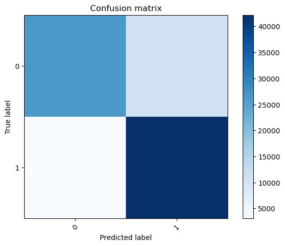

```
              precision    recall  f1-score   support

           0       0.89      0.71      0.79     36998
           1       0.80      0.93      0.86     45329

    accuracy                           0.83     82327
   macro avg       0.85      0.82      0.83     82327
weighted avg       0.84      0.83      0.83     82327
```

```python
import numpy as np

from sklearn import svm, datasets
from sklearn.model_selection import train_test_split
from sklearn.metrics import confusion_matrix, classification_report

label = encode_text_index(testing,"label")

# Compute confusion matrix
cm = confusion_matrix(y_test, y_predict)
print(cm)


print('Plotting confusion matrix')

plt.figure()
plot_confusion_matrix(cm, label)
plt.show()

print(classification_report(y_test, y_predict))
```

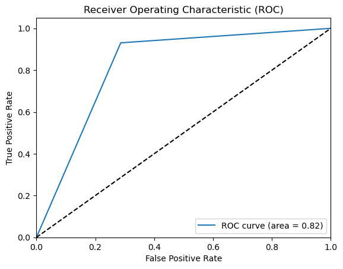

```python
plot_roc(y_predict,y_test)
```

### Support Vector Machine

```python
from sklearn.svm import SVC

svm = SVC(kernel='linear')
svm.fit(x_train, y_train)

y_predict = svm.predict(x_test)
```

```
[[33053  3945]
 [ 9102 36227]]
Plotting confusion matrix
```

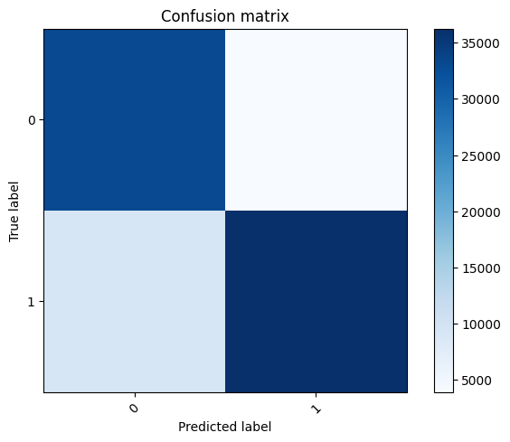

```
              precision    recall  f1-score   support

           0       0.78      0.89      0.84     36998
           1       0.90      0.80      0.85     45329

    accuracy                           0.84     82327
   macro avg       0.84      0.85      0.84     82327
weighted avg       0.85      0.84      0.84     82327
```

```python
# Compute confusion matrix
cm = confusion_matrix(y_test, y_predict)
print(cm)

print('Plotting confusion matrix')

plt.figure()
plot_confusion_matrix(cm, label)
plt.show()

print(classification_report(y_test, y_predict))
```

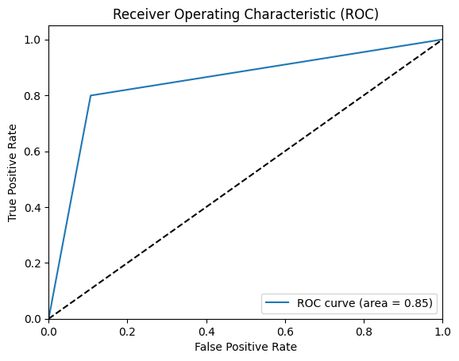

```python
plot_roc(y_predict,y_test)
```

# Neural Networks using Tensorflow

- Use EarlyStopping and ModelCheckpoint
- Activation: relu, sigmoid, tanh
- Optimizer: adam and sgd

### Fully-Connected Neural Networks

```python
x_train, y_train = to_xy(training.drop('attack_cat', axis=1), 'label')
x_test, y_test = to_xy(testing.drop('attack_cat', axis=1), 'label')
```

```python
x_train.shape
```

```
(175309, 191)
```

```python
y_train.shape
```

```
(175309, 2)
```

##### Fine Tuning hyperparameters using 'relu' and 'adam'

- Find best amount of neurons per input and hidden layers
- See how many hidden layers that will yield best result per model

```python
from tensorflow.keras.models import Sequential
from tensorflow.keras.layers import Dense, Activation
from tensorflow.keras.callbacks import EarlyStopping
from tensorflow.keras.callbacks import ModelCheckpoint


# Define ModelCheckpoint outside the loop
checkpointer = ModelCheckpoint(filepath="dnn/best_weights.hdf5", verbose=0, save_best_only=True) # save best model

for i in range(5):
    print(i)

    # Build network
    model = Sequential()
    model.add(Dense(20, input_dim=x_train.shape[1], activation='relu'))
    model.add(Dense(10, activation='relu'))
    model.add(Dense(y_train.shape[1], activation='softmax'))
    model.compile(loss='categorical_crossentropy', optimizer='adam')

    monitor = EarlyStopping(monitor='val_loss', min_delta=1e-3, patience=5, verbose=1, mode='auto')

    model.fit(x_train,y_train,validation_data=(x_test,y_test),callbacks=[monitor,checkpointer],verbose=2,epochs=1000)


print('Training finished...Loading the best model')
print()
model.load_weights('dnn/best_weights.hdf5') # load weights from best model

# Measure accuracy
pred = model.predict(x_test)
pred = np.argmax(pred,axis=1)

y_true = np.argmax(y_test,axis=1)
```

```
0
5479/5479 - 12s - loss: 0.1414 - val_loss: 0.2880 - 12s/epoch - 2ms/step
5479/5479 - 12s - loss: 0.1217 - val_loss: 0.2843 - 12s/epoch - 2ms/step
5479/5479 - 12s - loss: 0.1190 - val_loss: 0.3035 - 12s/epoch - 2ms/step
5479/5479 - 13s - loss: 0.1171 - val_loss: 0.3002 - 13s/epoch - 2ms/step
5479/5479 - 14s - loss: 0.1160 - val_loss: 0.2856 - 14s/epoch - 2ms/step
5479/5479 - 14s - loss: 0.1150 - val_loss: 0.2668 - 14s/epoch - 3ms/step
5479/5479 - 14s - loss: 0.1145 - val_loss: 0.2781 - 14s/epoch - 3ms/step
5479/5479 - 14s - loss: 0.1136 - val_loss: 0.3035 - 14s/epoch - 3ms/step
5479/5479 - 13s - loss: 0.1133 - val_loss: 0.2651 - 13s/epoch - 2ms/step
5479/5479 - 13s - loss: 0.1126 - val_loss: 0.2707 - 13s/epoch - 2ms/step
5479/5479 - 13s - loss: 0.1121 - val_loss: 0.2644 - 13s/epoch - 2ms/step
5479/5479 - 13s - loss: 0.1118 - val_loss: 0.2664 - 13s/epoch - 2ms/step
5479/5479 - 13s - loss: 0.1112 - val_loss: 0.2652 - 13s/epoch - 2ms/step
5479/5479 - 12s - loss: 0.1108 - val_loss: 0.2958 - 12s/epoch - 2ms/step
Epoch 14: early stopping
1
5479/5479 - 12s - loss: 0.1442 - val_loss: 0.3533 - 12s/epoch - 2ms/step
5479/5479 - 12s - loss: 0.1226 - val_loss: 0.3071 - 12s/epoch - 2ms/step
5479/5479 - 12s - loss: 0.1199 - val_loss: 0.3067 - 12s/epoch - 2ms/step
5479/5479 - 12s - loss: 0.1184 - val_loss: 0.2942 - 12s/epoch - 2ms/step
5479/5479 - 13s - loss: 0.1171 - val_loss: 0.2722 - 13s/epoch - 2ms/step
5479/5479 - 14s - loss: 0.1159 - val_loss: 0.3123 - 14s/epoch - 3ms/step
5479/5479 - 14s - loss: 0.1150 - val_loss: 0.3214 - 14s/epoch - 3ms/step
5479/5479 - 13s - loss: 0.1145 - val_loss: 0.2634 - 13s/epoch - 2ms/step
5479/5479 - 14s - loss: 0.1137 - val_loss: 0.3224 - 14s/epoch - 2ms/step
5479/5479 - 13s - loss: 0.1129 - val_loss: 0.3348 - 13s/epoch - 2ms/step
5479/5479 - 14s - loss: 0.1127 - val_loss: 0.2997 - 14s/epoch - 2ms/step
5479/5479 - 14s - loss: 0.1122 - val_loss: 0.2722 - 14s/epoch - 2ms/step
5479/5479 - 13s - loss: 0.1121 - val_loss: 0.2929 - 13s/epoch - 2ms/step
Epoch 13: early stopping
2
5479/5479 - 14s - loss: 0.1403 - val_loss: 0.4315 - 14s/epoch - 2ms/step
5479/5479 - 13s - loss: 0.1223 - val_loss: 0.3100 - 13s/epoch - 2ms/step
5479/5479 - 13s - loss: 0.1193 - val_loss: 0.3154 - 13s/epoch - 2ms/step
5479/5479 - 14s - loss: 0.1177 - val_loss: 0.3045 - 14s/epoch - 2ms/step
5479/5479 - 14s - loss: 0.1162 - val_loss: 0.2889 - 14s/epoch - 3ms/step
5479/5479 - 13s - loss: 0.1153 - val_loss: 0.2746 - 13s/epoch - 2ms/step
5479/5479 - 13s - loss: 0.1143 - val_loss: 0.2622 - 13s/epoch - 2ms/step
5479/5479 - 13s - loss: 0.1136 - val_loss: 0.2631 - 13s/epoch - 2ms/step
```

[output cut: 14 more lines]

```
4
5479/5479 - 14s - loss: 0.1421 - val_loss: 0.3560 - 14s/epoch - 2ms/step
5479/5479 - 13s - loss: 0.1230 - val_loss: 0.3435 - 13s/epoch - 2ms/step
5479/5479 - 13s - loss: 0.1198 - val_loss: 0.3125 - 13s/epoch - 2ms/step
5479/5479 - 13s - loss: 0.1180 - val_loss: 0.3292 - 13s/epoch - 2ms/step
5479/5479 - 12s - loss: 0.1164 - val_loss: 0.2928 - 12s/epoch - 2ms/step
5479/5479 - 12s - loss: 0.1157 - val_loss: 0.2908 - 12s/epoch - 2ms/step
5479/5479 - 13s - loss: 0.1147 - val_loss: 0.2725 - 13s/epoch - 2ms/step
5479/5479 - 12s - loss: 0.1138 - val_loss: 0.3187 - 12s/epoch - 2ms/step
5479/5479 - 13s - loss: 0.1132 - val_loss: 0.3012 - 13s/epoch - 2ms/step
5479/5479 - 13s - loss: 0.1127 - val_loss: 0.3242 - 13s/epoch - 2ms/step
5479/5479 - 14s - loss: 0.1120 - val_loss: 0.2804 - 14s/epoch - 2ms/step
5479/5479 - 13s - loss: 0.1118 - val_loss: 0.3304 - 13s/epoch - 2ms/step
Epoch 12: early stopping
Training finished...Loading the best model
```

```
[[25431 11567]
 [ 1086 44243]]
Plotting confusion matrix
```

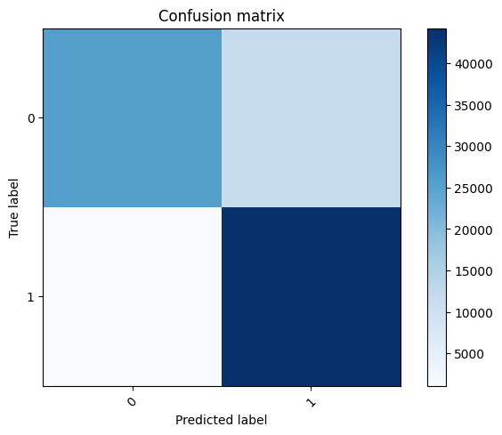

```
              precision    recall  f1-score   support

           0       0.96      0.69      0.80     36998
           1       0.79      0.98      0.87     45329

    accuracy                           0.85     82327
   macro avg       0.88      0.83      0.84     82327
weighted avg       0.87      0.85      0.84     82327
```

```python
# Compute confusion matrix
cm = confusion_matrix(y_true, pred)
print(cm)

print('Plotting confusion matrix')

plt.figure()
plot_confusion_matrix(cm, label)
plt.show()

print(classification_report(y_true, pred))
```

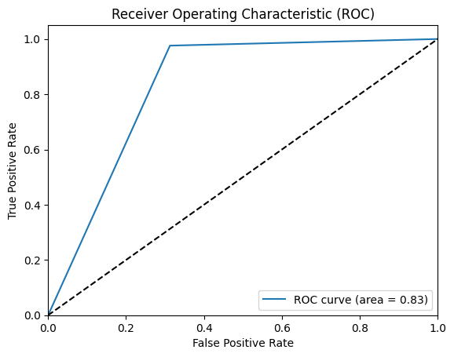

```python
plot_roc(pred,y_true)
```

```
0
5479/5479 - 14s - loss: 0.1312 - val_loss: 0.3092 - 14s/epoch - 3ms/step
5479/5479 - 13s - loss: 0.1193 - val_loss: 0.2874 - 13s/epoch - 2ms/step
5479/5479 - 13s - loss: 0.1164 - val_loss: 0.2756 - 13s/epoch - 2ms/step
5479/5479 - 13s - loss: 0.1142 - val_loss: 0.2750 - 13s/epoch - 2ms/step
5479/5479 - 14s - loss: 0.1130 - val_loss: 0.2600 - 14s/epoch - 2ms/step
5479/5479 - 14s - loss: 0.1111 - val_loss: 0.3078 - 14s/epoch - 3ms/step
5479/5479 - 13s - loss: 0.1103 - val_loss: 0.3348 - 13s/epoch - 2ms/step
5479/5479 - 13s - loss: 0.1104 - val_loss: 0.2708 - 13s/epoch - 2ms/step
5479/5479 - 13s - loss: 0.1095 - val_loss: 0.3354 - 13s/epoch - 2ms/step
5479/5479 - 13s - loss: 0.1080 - val_loss: 0.3202 - 13s/epoch - 2ms/step
Epoch 10: early stopping
1
5479/5479 - 14s - loss: 0.1311 - val_loss: 0.2927 - 14s/epoch - 2ms/step
5479/5479 - 14s - loss: 0.1196 - val_loss: 0.2823 - 14s/epoch - 3ms/step
5479/5479 - 13s - loss: 0.1163 - val_loss: 0.3036 - 13s/epoch - 2ms/step
5479/5479 - 14s - loss: 0.1144 - val_loss: 0.3067 - 14s/epoch - 2ms/step
5479/5479 - 13s - loss: 0.1127 - val_loss: 0.2855 - 13s/epoch - 2ms/step
5479/5479 - 13s - loss: 0.1115 - val_loss: 0.2953 - 13s/epoch - 2ms/step
5479/5479 - 13s - loss: 0.1104 - val_loss: 0.2912 - 13s/epoch - 2ms/step
Epoch 7: early stopping
2
5479/5479 - 13s - loss: 0.1308 - val_loss: 0.2729 - 13s/epoch - 2ms/step
5479/5479 - 13s - loss: 0.1194 - val_loss: 0.2945 - 13s/epoch - 2ms/step
5479/5479 - 12s - loss: 0.1166 - val_loss: 0.2811 - 12s/epoch - 2ms/step
5479/5479 - 13s - loss: 0.1153 - val_loss: 0.2954 - 13s/epoch - 2ms/step
5479/5479 - 13s - loss: 0.1133 - val_loss: 0.2719 - 13s/epoch - 2ms/step
5479/5479 - 13s - loss: 0.1117 - val_loss: 0.2756 - 13s/epoch - 2ms/step
5479/5479 - 13s - loss: 0.1102 - val_loss: 0.2648 - 13s/epoch - 2ms/step
5479/5479 - 13s - loss: 0.1098 - val_loss: 0.2774 - 13s/epoch - 2ms/step
5479/5479 - 13s - loss: 0.1089 - val_loss: 0.2830 - 13s/epoch - 2ms/step
5479/5479 - 13s - loss: 0.1081 - val_loss: 0.3008 - 13s/epoch - 2ms/step
5479/5479 - 13s - loss: 0.1073 - val_loss: 0.3375 - 13s/epoch - 2ms/step
5479/5479 - 13s - loss: 0.1071 - val_loss: 0.2949 - 13s/epoch - 2ms/step
Epoch 12: early stopping
3
5479/5479 - 14s - loss: 0.1308 - val_loss: 0.3423 - 14s/epoch - 2ms/step
5479/5479 - 13s - loss: 0.1191 - val_loss: 0.2991 - 13s/epoch - 2ms/step
5479/5479 - 13s - loss: 0.1164 - val_loss: 0.2763 - 13s/epoch - 2ms/step
5479/5479 - 13s - loss: 0.1147 - val_loss: 0.2825 - 13s/epoch - 2ms/step
5479/5479 - 13s - loss: 0.1129 - val_loss: 0.2867 - 13s/epoch - 2ms/step
5479/5479 - 13s - loss: 0.1119 - val_loss: 0.2802 - 13s/epoch - 2ms/step
5479/5479 - 12s - loss: 0.1106 - val_loss: 0.2915 - 12s/epoch - 2ms/step
5479/5479 - 13s - loss: 0.1104 - val_loss: 0.3262 - 13s/epoch - 2ms/step
Epoch 8: early stopping
4
5479/5479 - 13s - loss: 0.1316 - val_loss: 0.2977 - 13s/epoch - 2ms/step
5479/5479 - 13s - loss: 0.1195 - val_loss: 0.3259 - 13s/epoch - 2ms/step
5479/5479 - 13s - loss: 0.1163 - val_loss: 0.2798 - 13s/epoch - 2ms/step
5479/5479 - 13s - loss: 0.1143 - val_loss: 0.2856 - 13s/epoch - 2ms/step
5479/5479 - 14s - loss: 0.1132 - val_loss: 0.3253 - 14s/epoch - 2ms/step
5479/5479 - 13s - loss: 0.1118 - val_loss: 0.3221 - 13s/epoch - 2ms/step
5479/5479 - 14s - loss: 0.1104 - val_loss: 0.2807 - 14s/epoch - 3ms/step
5479/5479 - 13s - loss: 0.1097 - val_loss: 0.3016 - 13s/epoch - 2ms/step
Epoch 8: early stopping
Training finished...Loading the best model

[[26826 10172]
 [ 1389 43940]]
Plotting confusion matrix
```

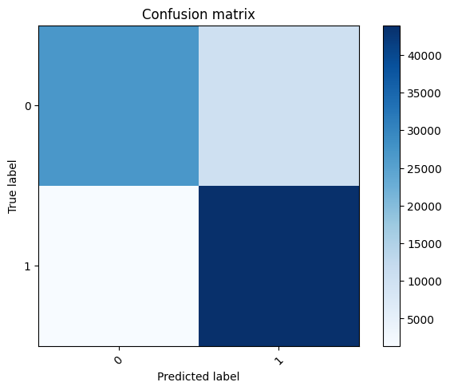

```
              precision    recall  f1-score   support

           0       0.95      0.73      0.82     36998
           1       0.81      0.97      0.88     45329

    accuracy                           0.86     82327
   macro avg       0.88      0.85      0.85     82327
weighted avg       0.87      0.86      0.86     82327
```

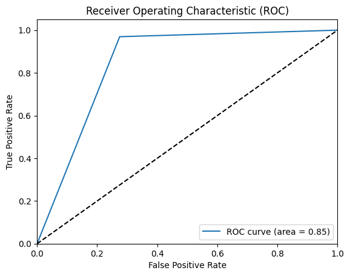

```python
# Define ModelCheckpoint outside the loop
checkpointer = ModelCheckpoint(filepath="dnn/best_weights.hdf5", verbose=0, save_best_only=True) # save best model

for i in range(5):
    print(i)

    # Build network
    model = Sequential()
    model.add(Dense(200, input_dim=x_train.shape[1], activation='relu'))
    model.add(Dense(100, activation='relu'))
    model.add(Dense(y_train.shape[1], activation='softmax'))
    model.compile(loss='categorical_crossentropy', optimizer='adam')

    monitor = EarlyStopping(monitor='val_loss', min_delta=1e-3, patience=5, verbose=1, mode='auto')

    model.fit(x_train,y_train,validation_data=(x_test,y_test),callbacks=[monitor,checkpointer],verbose=2,epochs=1000)


print('Training finished...Loading the best model')
print()
model.load_weights('dnn/best_weights.hdf5') # load weights from best model

# Measure accuracy
pred = model.predict(x_test)
pred = np.argmax(pred,axis=1)

y_true = np.argmax(y_test,axis=1)

# Compute confusion matrix
cm = confusion_matrix(y_true, pred)
print(cm)

print('Plotting confusion matrix')

plt.figure()
plot_confusion_matrix(cm, label)
plt.show()

print(classification_report(y_true, pred))

plot_roc(pred,y_true)
```

```
0
5479/5479 - 13s - loss: 0.1314 - val_loss: 0.3105 - 13s/epoch - 2ms/step
5479/5479 - 13s - loss: 0.1193 - val_loss: 0.3034 - 13s/epoch - 2ms/step
5479/5479 - 12s - loss: 0.1167 - val_loss: 0.3247 - 12s/epoch - 2ms/step
5479/5479 - 12s - loss: 0.1144 - val_loss: 0.2884 - 12s/epoch - 2ms/step
5479/5479 - 12s - loss: 0.1126 - val_loss: 0.3200 - 12s/epoch - 2ms/step
5479/5479 - 12s - loss: 0.1119 - val_loss: 0.2471 - 12s/epoch - 2ms/step
5479/5479 - 12s - loss: 0.1104 - val_loss: 0.2769 - 12s/epoch - 2ms/step
5479/5479 - 12s - loss: 0.1099 - val_loss: 0.3036 - 12s/epoch - 2ms/step
5479/5479 - 12s - loss: 0.1092 - val_loss: 0.3284 - 12s/epoch - 2ms/step
5479/5479 - 12s - loss: 0.1078 - val_loss: 0.2894 - 12s/epoch - 2ms/step
5479/5479 - 12s - loss: 0.1070 - val_loss: 0.3057 - 12s/epoch - 2ms/step
Epoch 11: early stopping
1
5479/5479 - 13s - loss: 0.1306 - val_loss: 0.3052 - 13s/epoch - 2ms/step
5479/5479 - 12s - loss: 0.1193 - val_loss: 0.2668 - 12s/epoch - 2ms/step
5479/5479 - 12s - loss: 0.1165 - val_loss: 0.2820 - 12s/epoch - 2ms/step
5479/5479 - 12s - loss: 0.1146 - val_loss: 0.3185 - 12s/epoch - 2ms/step
5479/5479 - 12s - loss: 0.1124 - val_loss: 0.3020 - 12s/epoch - 2ms/step
5479/5479 - 12s - loss: 0.1116 - val_loss: 0.2560 - 12s/epoch - 2ms/step
5479/5479 - 12s - loss: 0.1110 - val_loss: 0.2712 - 12s/epoch - 2ms/step
5479/5479 - 12s - loss: 0.1095 - val_loss: 0.3237 - 12s/epoch - 2ms/step
5479/5479 - 12s - loss: 0.1093 - val_loss: 0.2779 - 12s/epoch - 2ms/step
5479/5479 - 12s - loss: 0.1082 - val_loss: 0.3356 - 12s/epoch - 2ms/step
5479/5479 - 12s - loss: 0.1082 - val_loss: 0.3014 - 12s/epoch - 2ms/step
Epoch 11: early stopping
2
5479/5479 - 13s - loss: 0.1305 - val_loss: 0.2867 - 13s/epoch - 2ms/step
5479/5479 - 12s - loss: 0.1203 - val_loss: 0.2661 - 12s/epoch - 2ms/step
5479/5479 - 12s - loss: 0.1165 - val_loss: 0.3112 - 12s/epoch - 2ms/step
5479/5479 - 12s - loss: 0.1151 - val_loss: 0.2827 - 12s/epoch - 2ms/step
5479/5479 - 12s - loss: 0.1134 - val_loss: 0.2937 - 12s/epoch - 2ms/step
5479/5479 - 13s - loss: 0.1121 - val_loss: 0.3259 - 13s/epoch - 2ms/step
5479/5479 - 13s - loss: 0.1110 - val_loss: 0.3564 - 13s/epoch - 2ms/step
Epoch 7: early stopping
3
5479/5479 - 14s - loss: 0.1310 - val_loss: 0.2725 - 14s/epoch - 3ms/step
5479/5479 - 14s - loss: 0.1195 - val_loss: 0.2936 - 14s/epoch - 3ms/step
5479/5479 - 14s - loss: 0.1171 - val_loss: 0.2842 - 14s/epoch - 3ms/step
5479/5479 - 14s - loss: 0.1143 - val_loss: 0.2738 - 14s/epoch - 3ms/step
5479/5479 - 14s - loss: 0.1133 - val_loss: 0.2976 - 14s/epoch - 3ms/step
5479/5479 - 14s - loss: 0.1116 - val_loss: 0.2878 - 14s/epoch - 3ms/step
Epoch 6: early stopping
4
5479/5479 - 14s - loss: 0.1302 - val_loss: 0.2719 - 14s/epoch - 3ms/step
5479/5479 - 14s - loss: 0.1191 - val_loss: 0.2635 - 14s/epoch - 3ms/step
5479/5479 - 14s - loss: 0.1162 - val_loss: 0.2435 - 14s/epoch - 3ms/step
5479/5479 - 14s - loss: 0.1145 - val_loss: 0.2723 - 14s/epoch - 3ms/step
5479/5479 - 14s - loss: 0.1125 - val_loss: 0.2567 - 14s/epoch - 3ms/step
5479/5479 - 14s - loss: 0.1115 - val_loss: 0.3122 - 14s/epoch - 3ms/step
5479/5479 - 14s - loss: 0.1104 - val_loss: 0.3197 - 14s/epoch - 3ms/step
5479/5479 - 14s - loss: 0.1098 - val_loss: 0.2784 - 14s/epoch - 3ms/step
Epoch 8: early stopping
Training finished...Loading the best model

[[23620 13378]
 [  635 44694]]
Plotting confusion matrix
```

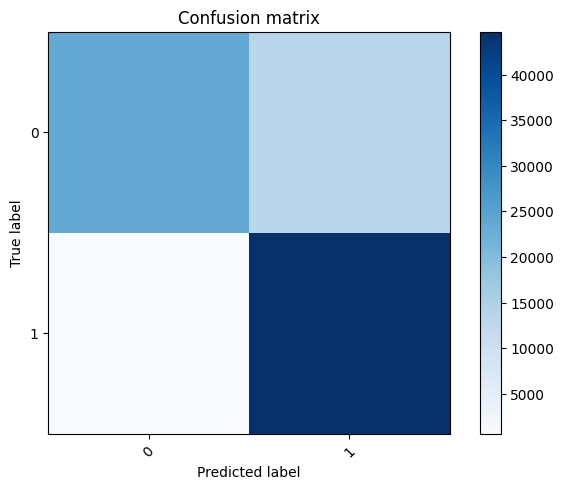

```
              precision    recall  f1-score   support

           0       0.97      0.64      0.77     36998
           1       0.77      0.99      0.86     45329

    accuracy                           0.83     82327
   macro avg       0.87      0.81      0.82     82327
weighted avg       0.86      0.83      0.82     82327
```

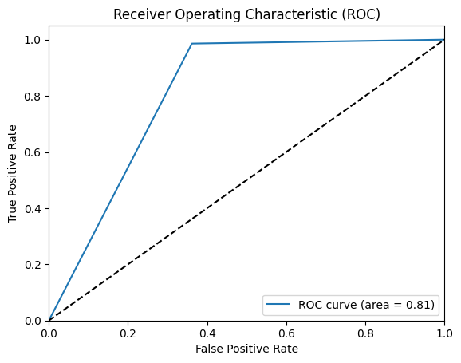

```python
# Define ModelCheckpoint outside the loop
checkpointer = ModelCheckpoint(filepath="dnn/best_weights.hdf5", verbose=0, save_best_only=True) # save best model

for i in range(5):
    print(i)

    # Build network
    model = Sequential()
    model.add(Dense(200, input_dim=x_train.shape[1], activation='relu'))
    model.add(Dense(100, activation='relu'))
    model.add(Dense(50, activation='relu'))
    model.add(Dense(y_train.shape[1], activation='softmax'))
    model.compile(loss='categorical_crossentropy', optimizer='adam')

    monitor = EarlyStopping(monitor='val_loss', min_delta=1e-3, patience=5, verbose=1, mode='auto')

    model.fit(x_train,y_train,validation_data=(x_test,y_test),callbacks=[monitor,checkpointer],verbose=2,epochs=1000)


print('Training finished...Loading the best model')
print()
model.load_weights('dnn/best_weights.hdf5') # load weights from best model

# Measure accuracy
pred = model.predict(x_test)
pred = np.argmax(pred,axis=1)

y_true = np.argmax(y_test,axis=1)

# Compute confusion matrix
cm = confusion_matrix(y_true, pred)
print(cm)

print('Plotting confusion matrix')

plt.figure()
plot_confusion_matrix(cm, label)
plt.show()

print(classification_report(y_true, pred))

plot_roc(pred,y_true)
```

```
0
5479/5479 - 16s - loss: 0.1316 - val_loss: 0.2822 - 16s/epoch - 3ms/step
5479/5479 - 15s - loss: 0.1204 - val_loss: 0.2975 - 15s/epoch - 3ms/step
5479/5479 - 16s - loss: 0.1167 - val_loss: 0.3469 - 16s/epoch - 3ms/step
5479/5479 - 16s - loss: 0.1148 - val_loss: 0.3156 - 16s/epoch - 3ms/step
5479/5479 - 15s - loss: 0.1131 - val_loss: 0.2977 - 15s/epoch - 3ms/step
5479/5479 - 15s - loss: 0.1120 - val_loss: 0.2737 - 15s/epoch - 3ms/step
5479/5479 - 15s - loss: 0.1104 - val_loss: 0.2800 - 15s/epoch - 3ms/step
5479/5479 - 15s - loss: 0.1101 - val_loss: 0.2683 - 15s/epoch - 3ms/step
5479/5479 - 15s - loss: 0.1088 - val_loss: 0.2765 - 15s/epoch - 3ms/step
5479/5479 - 15s - loss: 0.1080 - val_loss: 0.2722 - 15s/epoch - 3ms/step
5479/5479 - 14s - loss: 0.1073 - val_loss: 0.2737 - 14s/epoch - 3ms/step
5479/5479 - 15s - loss: 0.1070 - val_loss: 0.2877 - 15s/epoch - 3ms/step
5479/5479 - 14s - loss: 0.1062 - val_loss: 0.3040 - 14s/epoch - 3ms/step
Epoch 13: early stopping
1
5479/5479 - 15s - loss: 0.1312 - val_loss: 0.3303 - 15s/epoch - 3ms/step
5479/5479 - 15s - loss: 0.1199 - val_loss: 0.2778 - 15s/epoch - 3ms/step
5479/5479 - 15s - loss: 0.1173 - val_loss: 0.2597 - 15s/epoch - 3ms/step
5479/5479 - 15s - loss: 0.1147 - val_loss: 0.2979 - 15s/epoch - 3ms/step
5479/5479 - 15s - loss: 0.1132 - val_loss: 0.3090 - 15s/epoch - 3ms/step
5479/5479 - 14s - loss: 0.1118 - val_loss: 0.3164 - 14s/epoch - 3ms/step
5479/5479 - 15s - loss: 0.1107 - val_loss: 0.3167 - 15s/epoch - 3ms/step
5479/5479 - 15s - loss: 0.1096 - val_loss: 0.2604 - 15s/epoch - 3ms/step
Epoch 8: early stopping
2
5479/5479 - 15s - loss: 0.1321 - val_loss: 0.3156 - 15s/epoch - 3ms/step
5479/5479 - 15s - loss: 0.1201 - val_loss: 0.2772 - 15s/epoch - 3ms/step
5479/5479 - 15s - loss: 0.1170 - val_loss: 0.2962 - 15s/epoch - 3ms/step
5479/5479 - 15s - loss: 0.1145 - val_loss: 0.2854 - 15s/epoch - 3ms/step
5479/5479 - 16s - loss: 0.1134 - val_loss: 0.2726 - 16s/epoch - 3ms/step
5479/5479 - 15s - loss: 0.1120 - val_loss: 0.2640 - 15s/epoch - 3ms/step
5479/5479 - 15s - loss: 0.1106 - val_loss: 0.2904 - 15s/epoch - 3ms/step
5479/5479 - 15s - loss: 0.1102 - val_loss: 0.2967 - 15s/epoch - 3ms/step
5479/5479 - 15s - loss: 0.1093 - val_loss: 0.2914 - 15s/epoch - 3ms/step
5479/5479 - 15s - loss: 0.1081 - val_loss: 0.2783 - 15s/epoch - 3ms/step
5479/5479 - 15s - loss: 0.1077 - val_loss: 0.3112 - 15s/epoch - 3ms/step
Epoch 11: early stopping
3
5479/5479 - 15s - loss: 0.1305 - val_loss: 0.3119 - 15s/epoch - 3ms/step
```

[output cut: 8 more lines]

```
Epoch 9: early stopping
4
5479/5479 - 16s - loss: 0.1312 - val_loss: 0.3271 - 16s/epoch - 3ms/step
5479/5479 - 15s - loss: 0.1205 - val_loss: 0.2603 - 15s/epoch - 3ms/step
5479/5479 - 15s - loss: 0.1171 - val_loss: 0.3035 - 15s/epoch - 3ms/step
5479/5479 - 16s - loss: 0.1151 - val_loss: 0.3029 - 16s/epoch - 3ms/step
5479/5479 - 15s - loss: 0.1133 - val_loss: 0.3114 - 15s/epoch - 3ms/step
5479/5479 - 15s - loss: 0.1125 - val_loss: 0.3120 - 15s/epoch - 3ms/step
5479/5479 - 14s - loss: 0.1112 - val_loss: 0.2828 - 14s/epoch - 3ms/step
Epoch 7: early stopping
Training finished...Loading the best model

[[25380 11618]
 [ 1157 44172]]
Plotting confusion matrix
```

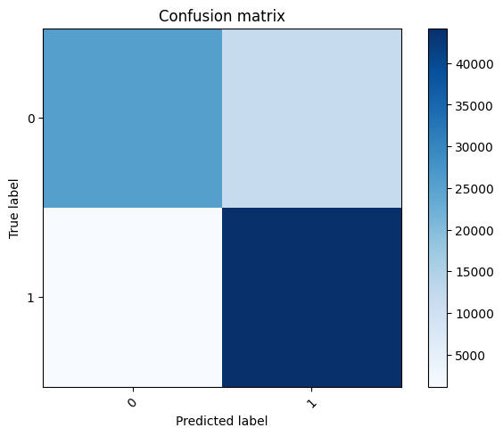

```
              precision    recall  f1-score   support

           0       0.96      0.69      0.80     36998
           1       0.79      0.97      0.87     45329

    accuracy                           0.84     82327
   macro avg       0.87      0.83      0.84     82327
weighted avg       0.87      0.84      0.84     82327
```

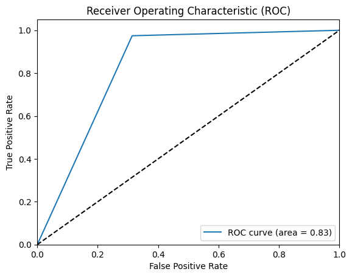

```python
# Define ModelCheckpoint outside the loop
checkpointer = ModelCheckpoint(filepath="dnn/best_weights.hdf5", verbose=0, save_best_only=True) # save best model

for i in range(5):
    print(i)

    # Build network
    model = Sequential()
    model.add(Dense(200, input_dim=x_train.shape[1], activation='relu'))
    model.add(Dense(100, activation='relu'))
    model.add(Dense(50, activation='relu'))
    model.add(Dense(25, activation='relu'))
    model.add(Dense(y_train.shape[1], activation='softmax'))
    model.compile(loss='categorical_crossentropy', optimizer='adam')

    monitor = EarlyStopping(monitor='val_loss', min_delta=1e-3, patience=5, verbose=1, mode='auto')

    model.fit(x_train,y_train,validation_data=(x_test,y_test),callbacks=[monitor,checkpointer],verbose=2,epochs=1000)


print('Training finished...Loading the best model')
print()
model.load_weights('dnn/best_weights.hdf5') # load weights from best model

# Measure accuracy
pred = model.predict(x_test)
pred = np.argmax(pred,axis=1)

y_true = np.argmax(y_test,axis=1)

# Compute confusion matrix
cm = confusion_matrix(y_true, pred)
print(cm)

print('Plotting confusion matrix')

plt.figure()
plot_confusion_matrix(cm, label)
plt.show()

print(classification_report(y_true, pred))

plot_roc(pred,y_true)
```

```
0
5479/5479 - 13s - loss: 0.1308 - val_loss: 0.2751 - 13s/epoch - 2ms/step
5479/5479 - 13s - loss: 0.1193 - val_loss: 0.3238 - 13s/epoch - 2ms/step
5479/5479 - 13s - loss: 0.1161 - val_loss: 0.2972 - 13s/epoch - 2ms/step
5479/5479 - 13s - loss: 0.1144 - val_loss: 0.2694 - 13s/epoch - 2ms/step
5479/5479 - 13s - loss: 0.1124 - val_loss: 0.2745 - 13s/epoch - 2ms/step
5479/5479 - 13s - loss: 0.1110 - val_loss: 0.2791 - 13s/epoch - 2ms/step
5479/5479 - 13s - loss: 0.1103 - val_loss: 0.2684 - 13s/epoch - 2ms/step
5479/5479 - 13s - loss: 0.1092 - val_loss: 0.3287 - 13s/epoch - 2ms/step
5479/5479 - 14s - loss: 0.1088 - val_loss: 0.3196 - 14s/epoch - 2ms/step
5479/5479 - 14s - loss: 0.1077 - val_loss: 0.3454 - 14s/epoch - 2ms/step
5479/5479 - 14s - loss: 0.1073 - val_loss: 0.2926 - 14s/epoch - 3ms/step
5479/5479 - 13s - loss: 0.1073 - val_loss: 0.2921 - 13s/epoch - 2ms/step
Epoch 12: early stopping
1
5479/5479 - 13s - loss: 0.1302 - val_loss: 0.3027 - 13s/epoch - 2ms/step
5479/5479 - 13s - loss: 0.1195 - val_loss: 0.2747 - 13s/epoch - 2ms/step
5479/5479 - 13s - loss: 0.1165 - val_loss: 0.2856 - 13s/epoch - 2ms/step
5479/5479 - 13s - loss: 0.1141 - val_loss: 0.2606 - 13s/epoch - 2ms/step
5479/5479 - 14s - loss: 0.1128 - val_loss: 0.2761 - 14s/epoch - 2ms/step
5479/5479 - 14s - loss: 0.1113 - val_loss: 0.2756 - 14s/epoch - 2ms/step
5479/5479 - 13s - loss: 0.1099 - val_loss: 0.2845 - 13s/epoch - 2ms/step
5479/5479 - 13s - loss: 0.1089 - val_loss: 0.2879 - 13s/epoch - 2ms/step
5479/5479 - 13s - loss: 0.1081 - val_loss: 0.2637 - 13s/epoch - 2ms/step
Epoch 9: early stopping
2
5479/5479 - 14s - loss: 0.1299 - val_loss: 0.3240 - 14s/epoch - 2ms/step
5479/5479 - 13s - loss: 0.1193 - val_loss: 0.2928 - 13s/epoch - 2ms/step
5479/5479 - 13s - loss: 0.1166 - val_loss: 0.2474 - 13s/epoch - 2ms/step
5479/5479 - 13s - loss: 0.1142 - val_loss: 0.2784 - 13s/epoch - 2ms/step
5479/5479 - 13s - loss: 0.1129 - val_loss: 0.3136 - 13s/epoch - 2ms/step
5479/5479 - 13s - loss: 0.1114 - val_loss: 0.2986 - 13s/epoch - 2ms/step
5479/5479 - 13s - loss: 0.1102 - val_loss: 0.3210 - 13s/epoch - 2ms/step
5479/5479 - 13s - loss: 0.1101 - val_loss: 0.2905 - 13s/epoch - 2ms/step
Epoch 8: early stopping
3
5479/5479 - 14s - loss: 0.1298 - val_loss: 0.3220 - 14s/epoch - 3ms/step
5479/5479 - 13s - loss: 0.1191 - val_loss: 0.3038 - 13s/epoch - 2ms/step
5479/5479 - 13s - loss: 0.1163 - val_loss: 0.2717 - 13s/epoch - 2ms/step
5479/5479 - 13s - loss: 0.1138 - val_loss: 0.3001 - 13s/epoch - 2ms/step
```

[output cut: 9 more lines]

```
5479/5479 - 13s - loss: 0.1143 - val_loss: 0.3174 - 13s/epoch - 2ms/step
5479/5479 - 13s - loss: 0.1130 - val_loss: 0.2901 - 13s/epoch - 2ms/step
5479/5479 - 13s - loss: 0.1116 - val_loss: 0.3196 - 13s/epoch - 2ms/step
5479/5479 - 13s - loss: 0.1110 - val_loss: 0.2725 - 13s/epoch - 2ms/step
5479/5479 - 13s - loss: 0.1095 - val_loss: 0.2716 - 13s/epoch - 2ms/step
5479/5479 - 13s - loss: 0.1094 - val_loss: 0.3450 - 13s/epoch - 2ms/step
5479/5479 - 13s - loss: 0.1084 - val_loss: 0.3048 - 13s/epoch - 2ms/step
5479/5479 - 13s - loss: 0.1079 - val_loss: 0.3178 - 13s/epoch - 2ms/step
5479/5479 - 13s - loss: 0.1071 - val_loss: 0.2995 - 13s/epoch - 2ms/step
Epoch 12: early stopping
Training finished...Loading the best model

[[25332 11666]
 [ 1062 44267]]
Plotting confusion matrix
```

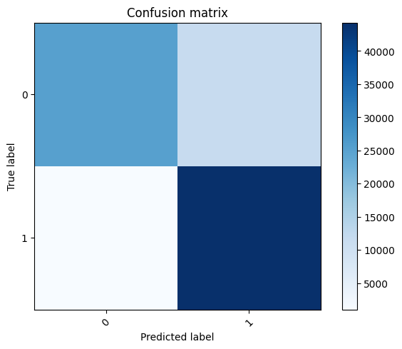

```
              precision    recall  f1-score   support

           0       0.96      0.68      0.80     36998
           1       0.79      0.98      0.87     45329

    accuracy                           0.85     82327
   macro avg       0.88      0.83      0.84     82327
weighted avg       0.87      0.85      0.84     82327
```

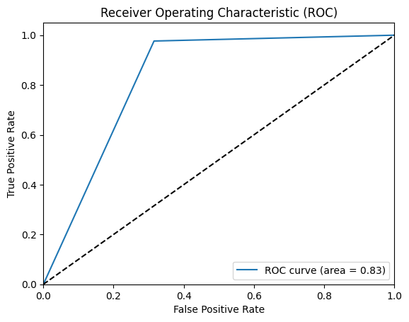

```python
# Define ModelCheckpoint outside the loop
checkpointer = ModelCheckpoint(filepath="dnn/best_weights.hdf5", verbose=0, save_best_only=True) # save best model

for i in range(5):
    print(i)

    # Build network
    model = Sequential()
    model.add(Dense(x_train.shape[1], input_dim=x_train.shape[1], activation='relu'))
    model.add(Dense(200, activation='relu'))
    model.add(Dense(y_train.shape[1], activation='softmax'))
    model.compile(loss='categorical_crossentropy', optimizer='adam')

    monitor = EarlyStopping(monitor='val_loss', min_delta=1e-3, patience=5, verbose=1, mode='auto')

    model.fit(x_train,y_train,validation_data=(x_test,y_test),callbacks=[monitor,checkpointer],verbose=2,epochs=1000)


print('Training finished...Loading the best model')
print()
model.load_weights('dnn/best_weights.hdf5') # load weights from best model

# Measure accuracy
pred = model.predict(x_test)
pred = np.argmax(pred,axis=1)

y_true = np.argmax(y_test,axis=1)

# Compute confusion matrix
cm = confusion_matrix(y_true, pred)
print(cm)

print('Plotting confusion matrix')

plt.figure()
plot_confusion_matrix(cm, label)
plt.show()

print(classification_report(y_true, pred))

plot_roc(pred,y_true)
```

```
0
5479/5479 - 14s - loss: 0.1306 - val_loss: 0.3196 - 14s/epoch - 3ms/step
5479/5479 - 14s - loss: 0.1200 - val_loss: 0.2649 - 14s/epoch - 3ms/step
5479/5479 - 14s - loss: 0.1168 - val_loss: 0.2705 - 14s/epoch - 3ms/step
5479/5479 - 14s - loss: 0.1147 - val_loss: 0.3234 - 14s/epoch - 2ms/step
5479/5479 - 14s - loss: 0.1132 - val_loss: 0.2744 - 14s/epoch - 3ms/step
5479/5479 - 14s - loss: 0.1117 - val_loss: 0.2849 - 14s/epoch - 2ms/step
5479/5479 - 15s - loss: 0.1107 - val_loss: 0.2880 - 15s/epoch - 3ms/step
Epoch 7: early stopping
1
5479/5479 - 15s - loss: 0.1308 - val_loss: 0.2583 - 15s/epoch - 3ms/step
5479/5479 - 13s - loss: 0.1201 - val_loss: 0.2901 - 13s/epoch - 2ms/step
5479/5479 - 14s - loss: 0.1165 - val_loss: 0.2609 - 14s/epoch - 3ms/step
5479/5479 - 12s - loss: 0.1144 - val_loss: 0.2487 - 12s/epoch - 2ms/step
5479/5479 - 13s - loss: 0.1131 - val_loss: 0.3058 - 13s/epoch - 2ms/step
5479/5479 - 12s - loss: 0.1116 - val_loss: 0.2786 - 12s/epoch - 2ms/step
5479/5479 - 12s - loss: 0.1110 - val_loss: 0.3025 - 12s/epoch - 2ms/step
5479/5479 - 12s - loss: 0.1099 - val_loss: 0.3021 - 12s/epoch - 2ms/step
5479/5479 - 13s - loss: 0.1097 - val_loss: 0.2781 - 13s/epoch - 2ms/step
Epoch 9: early stopping
2
5479/5479 - 13s - loss: 0.1302 - val_loss: 0.3465 - 13s/epoch - 2ms/step
5479/5479 - 12s - loss: 0.1194 - val_loss: 0.3520 - 12s/epoch - 2ms/step
5479/5479 - 12s - loss: 0.1163 - val_loss: 0.2971 - 12s/epoch - 2ms/step
5479/5479 - 13s - loss: 0.1141 - val_loss: 0.3363 - 13s/epoch - 2ms/step
5479/5479 - 14s - loss: 0.1125 - val_loss: 0.3021 - 14s/epoch - 3ms/step
5479/5479 - 14s - loss: 0.1115 - val_loss: 0.3394 - 14s/epoch - 3ms/step
5479/5479 - 14s - loss: 0.1105 - val_loss: 0.3051 - 14s/epoch - 3ms/step
5479/5479 - 13s - loss: 0.1097 - val_loss: 0.2891 - 13s/epoch - 2ms/step
5479/5479 - 13s - loss: 0.1123 - val_loss: 0.2591 - 13s/epoch - 2ms/step
5479/5479 - 13s - loss: 0.1079 - val_loss: 0.2908 - 13s/epoch - 2ms/step
5479/5479 - 13s - loss: 0.1075 - val_loss: 0.2944 - 13s/epoch - 2ms/step
5479/5479 - 11s - loss: 0.1077 - val_loss: 0.3069 - 11s/epoch - 2ms/step
5479/5479 - 12s - loss: 0.1062 - val_loss: 0.3241 - 12s/epoch - 2ms/step
5479/5479 - 12s - loss: 0.1060 - val_loss: 0.3129 - 12s/epoch - 2ms/step
Epoch 14: early stopping
3
5479/5479 - 12s - loss: 0.1307 - val_loss: 0.2989 - 12s/epoch - 2ms/step
5479/5479 - 12s - loss: 0.1197 - val_loss: 0.2672 - 12s/epoch - 2ms/step
5479/5479 - 12s - loss: 0.1172 - val_loss: 0.2846 - 12s/epoch - 2ms/step
```

[output cut: 12 more lines]

```
5479/5479 - 13s - loss: 0.1105 - val_loss: 0.2947 - 13s/epoch - 2ms/step
5479/5479 - 13s - loss: 0.1098 - val_loss: 0.2907 - 13s/epoch - 2ms/step
5479/5479 - 13s - loss: 0.1109 - val_loss: 0.2999 - 13s/epoch - 2ms/step
5479/5479 - 14s - loss: 0.1082 - val_loss: 0.2612 - 14s/epoch - 2ms/step
5479/5479 - 14s - loss: 0.1075 - val_loss: 0.2920 - 14s/epoch - 3ms/step
5479/5479 - 14s - loss: 0.1070 - val_loss: 0.3062 - 14s/epoch - 3ms/step
5479/5479 - 13s - loss: 0.1065 - val_loss: 0.3233 - 13s/epoch - 2ms/step
5479/5479 - 13s - loss: 0.1068 - val_loss: 0.3220 - 13s/epoch - 2ms/step
5479/5479 - 13s - loss: 0.1061 - val_loss: 0.3147 - 13s/epoch - 2ms/step
Epoch 15: early stopping
Training finished...Loading the best model

[[25300 11698]
 [  949 44380]]
Plotting confusion matrix
```

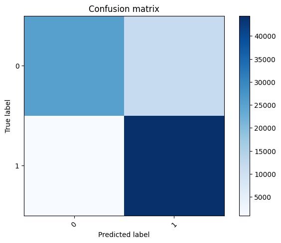

```
              precision    recall  f1-score   support

           0       0.96      0.68      0.80     36998
           1       0.79      0.98      0.88     45329

    accuracy                           0.85     82327
   macro avg       0.88      0.83      0.84     82327
weighted avg       0.87      0.85      0.84     82327
```

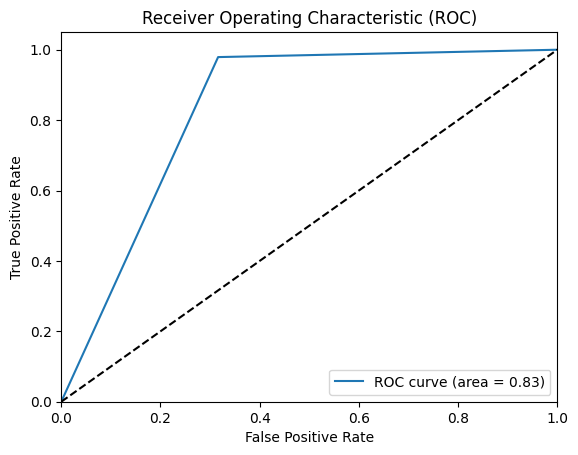

```python
# Define ModelCheckpoint outside the loop
checkpointer = ModelCheckpoint(filepath="dnn/best_weights.hdf5", verbose=0, save_best_only=True) # save best model

for i in range(5):
    print(i)

    # Build network
    model = Sequential()
    model.add(Dense(x_train.shape[1], input_dim=x_train.shape[1], activation='relu'))
    model.add(Dense(200, activation='relu'))
    model.add(Dense(100, activation='relu'))
    model.add(Dense(y_train.shape[1], activation='softmax'))
    model.compile(loss='categorical_crossentropy', optimizer='adam')

    monitor = EarlyStopping(monitor='val_loss', min_delta=1e-3, patience=5, verbose=1, mode='auto')

    model.fit(x_train,y_train,validation_data=(x_test,y_test),callbacks=[monitor,checkpointer],verbose=2,epochs=1000)


print('Training finished...Loading the best model')
print()
model.load_weights('dnn/best_weights.hdf5') # load weights from best model

# Measure accuracy
pred = model.predict(x_test)
pred = np.argmax(pred,axis=1)

y_true = np.argmax(y_test,axis=1)

# Compute confusion matrix
cm = confusion_matrix(y_true, pred)
print(cm)

print('Plotting confusion matrix')

plt.figure()
plot_confusion_matrix(cm, label)
plt.show()

print(classification_report(y_true, pred))

plot_roc(pred,y_true)
```

```
0
5479/5479 - 12s - loss: 0.1314 - val_loss: 0.2730 - 12s/epoch - 2ms/step
5479/5479 - 14s - loss: 0.1197 - val_loss: 0.2948 - 14s/epoch - 3ms/step
5479/5479 - 14s - loss: 0.1174 - val_loss: 0.3098 - 14s/epoch - 3ms/step
5479/5479 - 14s - loss: 0.1151 - val_loss: 0.2830 - 14s/epoch - 3ms/step
5479/5479 - 13s - loss: 0.1137 - val_loss: 0.2613 - 13s/epoch - 2ms/step
5479/5479 - 14s - loss: 0.1120 - val_loss: 0.3096 - 14s/epoch - 3ms/step
5479/5479 - 14s - loss: 0.1108 - val_loss: 0.2823 - 14s/epoch - 2ms/step
5479/5479 - 14s - loss: 0.1103 - val_loss: 0.2772 - 14s/epoch - 3ms/step
5479/5479 - 15s - loss: 0.1089 - val_loss: 0.2715 - 15s/epoch - 3ms/step
5479/5479 - 16s - loss: 0.1085 - val_loss: 0.2979 - 16s/epoch - 3ms/step
Epoch 10: early stopping
1
5479/5479 - 16s - loss: 0.1313 - val_loss: 0.3021 - 16s/epoch - 3ms/step
5479/5479 - 15s - loss: 0.1206 - val_loss: 0.2564 - 15s/epoch - 3ms/step
5479/5479 - 15s - loss: 0.1165 - val_loss: 0.3122 - 15s/epoch - 3ms/step
5479/5479 - 15s - loss: 0.1146 - val_loss: 0.2771 - 15s/epoch - 3ms/step
5479/5479 - 15s - loss: 0.1134 - val_loss: 0.2622 - 15s/epoch - 3ms/step
5479/5479 - 15s - loss: 0.1118 - val_loss: 0.3318 - 15s/epoch - 3ms/step
5479/5479 - 14s - loss: 0.1105 - val_loss: 0.2790 - 14s/epoch - 3ms/step
Epoch 7: early stopping
2
5479/5479 - 15s - loss: 0.1310 - val_loss: 0.3203 - 15s/epoch - 3ms/step
5479/5479 - 14s - loss: 0.1198 - val_loss: 0.3002 - 14s/epoch - 3ms/step
5479/5479 - 14s - loss: 0.1167 - val_loss: 0.3586 - 14s/epoch - 3ms/step
5479/5479 - 14s - loss: 0.1144 - val_loss: 0.2461 - 14s/epoch - 3ms/step
5479/5479 - 15s - loss: 0.1133 - val_loss: 0.2725 - 15s/epoch - 3ms/step
5479/5479 - 15s - loss: 0.1116 - val_loss: 0.2956 - 15s/epoch - 3ms/step
5479/5479 - 15s - loss: 0.1103 - val_loss: 0.2867 - 15s/epoch - 3ms/step
5479/5479 - 14s - loss: 0.1092 - val_loss: 0.2881 - 14s/epoch - 3ms/step
5479/5479 - 14s - loss: 0.1085 - val_loss: 0.3235 - 14s/epoch - 3ms/step
Epoch 9: early stopping
3
5479/5479 - 15s - loss: 0.1307 - val_loss: 0.3160 - 15s/epoch - 3ms/step
5479/5479 - 15s - loss: 0.1198 - val_loss: 0.3163 - 15s/epoch - 3ms/step
5479/5479 - 14s - loss: 0.1169 - val_loss: 0.3096 - 14s/epoch - 3ms/step
5479/5479 - 14s - loss: 0.1145 - val_loss: 0.2958 - 14s/epoch - 3ms/step
5479/5479 - 14s - loss: 0.1135 - val_loss: 0.2741 - 14s/epoch - 3ms/step
5479/5479 - 14s - loss: 0.1122 - val_loss: 0.2823 - 14s/epoch - 3ms/step
5479/5479 - 14s - loss: 0.1105 - val_loss: 0.3558 - 14s/epoch - 3ms/step
```

[output cut: 8 more lines]

```
5479/5479 - 15s - loss: 0.1151 - val_loss: 0.3306 - 15s/epoch - 3ms/step
5479/5479 - 16s - loss: 0.1137 - val_loss: 0.3235 - 16s/epoch - 3ms/step
5479/5479 - 16s - loss: 0.1117 - val_loss: 0.2753 - 16s/epoch - 3ms/step
5479/5479 - 15s - loss: 0.1111 - val_loss: 0.2427 - 15s/epoch - 3ms/step
5479/5479 - 13s - loss: 0.1099 - val_loss: 0.3229 - 13s/epoch - 2ms/step
5479/5479 - 13s - loss: 0.1101 - val_loss: 0.3276 - 13s/epoch - 2ms/step
5479/5479 - 13s - loss: 0.1086 - val_loss: 0.2786 - 13s/epoch - 2ms/step
5479/5479 - 14s - loss: 0.1086 - val_loss: 0.2559 - 14s/epoch - 2ms/step
5479/5479 - 13s - loss: 0.1068 - val_loss: 0.3074 - 13s/epoch - 2ms/step
Epoch 12: early stopping
Training finished...Loading the best model

[[26879 10119]
 [ 1347 43982]]
Plotting confusion matrix
```

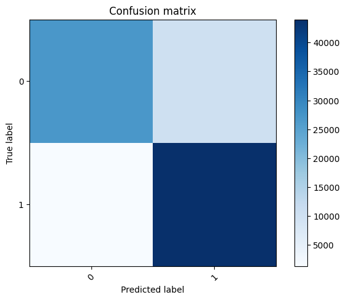

```
              precision    recall  f1-score   support

           0       0.95      0.73      0.82     36998
           1       0.81      0.97      0.88     45329

    accuracy                           0.86     82327
   macro avg       0.88      0.85      0.85     82327
weighted avg       0.88      0.86      0.86     82327
```

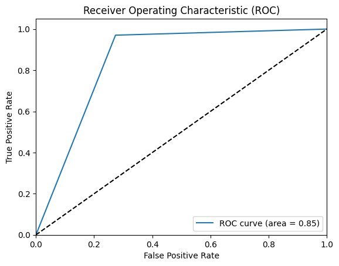

```python
# Define ModelCheckpoint outside the loop
checkpointer = ModelCheckpoint(filepath="dnn/best_weights.hdf5", verbose=0, save_best_only=True) # save best model

for i in range(5):
    print(i)

    # Build network
    model = Sequential()
    model.add(Dense(x_train.shape[1], input_dim=x_train.shape[1], activation='relu'))
    model.add(Dense(200, activation='relu'))
    model.add(Dense(100, activation='relu'))
    model.add(Dense(50, activation='relu'))
    model.add(Dense(y_train.shape[1], activation='softmax'))
    model.compile(loss='categorical_crossentropy', optimizer='adam')

    monitor = EarlyStopping(monitor='val_loss', min_delta=1e-3, patience=5, verbose=1, mode='auto')

    model.fit(x_train,y_train,validation_data=(x_test,y_test),callbacks=[monitor,checkpointer],verbose=2,epochs=1000)


print('Training finished...Loading the best model')
print()
model.load_weights('dnn/best_weights.hdf5') # load weights from best model

# Measure accuracy
pred = model.predict(x_test)
pred = np.argmax(pred,axis=1)

y_true = np.argmax(y_test,axis=1)

# Compute confusion matrix
cm = confusion_matrix(y_true, pred)
print(cm)

print('Plotting confusion matrix')

plt.figure()
plot_confusion_matrix(cm, label)
plt.show()

print(classification_report(y_true, pred))

plot_roc(pred,y_true)
```

```
0
5479/5479 - 15s - loss: 0.1317 - val_loss: 0.2986 - 15s/epoch - 3ms/step
5479/5479 - 15s - loss: 0.1205 - val_loss: 0.3374 - 15s/epoch - 3ms/step
5479/5479 - 15s - loss: 0.1173 - val_loss: 0.3346 - 15s/epoch - 3ms/step
5479/5479 - 17s - loss: 0.1160 - val_loss: 0.3131 - 17s/epoch - 3ms/step
5479/5479 - 17s - loss: 0.1132 - val_loss: 0.3080 - 17s/epoch - 3ms/step
5479/5479 - 17s - loss: 0.1127 - val_loss: 0.2872 - 17s/epoch - 3ms/step
5479/5479 - 14s - loss: 0.1115 - val_loss: 0.2714 - 14s/epoch - 3ms/step
5479/5479 - 14s - loss: 0.1108 - val_loss: 0.2873 - 14s/epoch - 3ms/step
5479/5479 - 14s - loss: 0.1101 - val_loss: 0.2757 - 14s/epoch - 3ms/step
5479/5479 - 15s - loss: 0.1094 - val_loss: 0.3851 - 15s/epoch - 3ms/step
5479/5479 - 15s - loss: 0.1086 - val_loss: 0.3089 - 15s/epoch - 3ms/step
5479/5479 - 15s - loss: 0.1082 - val_loss: 0.3039 - 15s/epoch - 3ms/step
Epoch 12: early stopping
1
5479/5479 - 16s - loss: 0.1316 - val_loss: 0.2713 - 16s/epoch - 3ms/step
5479/5479 - 13s - loss: 0.1198 - val_loss: 0.2550 - 13s/epoch - 2ms/step
5479/5479 - 15s - loss: 0.1175 - val_loss: 0.3012 - 15s/epoch - 3ms/step
5479/5479 - 15s - loss: 0.1149 - val_loss: 0.3126 - 15s/epoch - 3ms/step
5479/5479 - 16s - loss: 0.1133 - val_loss: 0.2934 - 16s/epoch - 3ms/step
5479/5479 - 16s - loss: 0.1127 - val_loss: 0.2619 - 16s/epoch - 3ms/step
5479/5479 - 15s - loss: 0.1109 - val_loss: 0.2744 - 15s/epoch - 3ms/step
Epoch 7: early stopping
2
5479/5479 - 15s - loss: 0.1316 - val_loss: 0.3597 - 15s/epoch - 3ms/step
5479/5479 - 14s - loss: 0.1199 - val_loss: 0.3101 - 14s/epoch - 3ms/step
5479/5479 - 14s - loss: 0.1174 - val_loss: 0.2784 - 14s/epoch - 3ms/step
5479/5479 - 14s - loss: 0.1157 - val_loss: 0.2707 - 14s/epoch - 2ms/step
5479/5479 - 13s - loss: 0.1138 - val_loss: 0.3066 - 13s/epoch - 2ms/step
5479/5479 - 13s - loss: 0.1120 - val_loss: 0.2990 - 13s/epoch - 2ms/step
5479/5479 - 13s - loss: 0.1114 - val_loss: 0.2834 - 13s/epoch - 2ms/step
5479/5479 - 14s - loss: 0.1101 - val_loss: 0.3114 - 14s/epoch - 2ms/step
5479/5479 - 16s - loss: 0.1096 - val_loss: 0.2740 - 16s/epoch - 3ms/step
Epoch 9: early stopping
3
5479/5479 - 16s - loss: 0.1316 - val_loss: 0.2869 - 16s/epoch - 3ms/step
5479/5479 - 14s - loss: 0.1201 - val_loss: 0.2603 - 14s/epoch - 3ms/step
5479/5479 - 14s - loss: 0.1175 - val_loss: 0.2868 - 14s/epoch - 2ms/step
5479/5479 - 15s - loss: 0.1148 - val_loss: 0.2399 - 15s/epoch - 3ms/step
5479/5479 - 15s - loss: 0.1136 - val_loss: 0.2468 - 15s/epoch - 3ms/step
5479/5479 - 15s - loss: 0.1122 - val_loss: 0.2698 - 15s/epoch - 3ms/step
5479/5479 - 16s - loss: 0.1115 - val_loss: 0.2940 - 16s/epoch - 3ms/step
5479/5479 - 16s - loss: 0.1112 - val_loss: 0.2883 - 16s/epoch - 3ms/step
5479/5479 - 16s - loss: 0.1095 - val_loss: 0.2788 - 16s/epoch - 3ms/step
Epoch 9: early stopping
4
5479/5479 - 17s - loss: 0.1312 - val_loss: 0.2940 - 17s/epoch - 3ms/step
5479/5479 - 16s - loss: 0.1205 - val_loss: 0.2380 - 16s/epoch - 3ms/step
5479/5479 - 17s - loss: 0.1172 - val_loss: 0.2736 - 17s/epoch - 3ms/step
5479/5479 - 15s - loss: 0.1155 - val_loss: 0.2767 - 15s/epoch - 3ms/step
5479/5479 - 15s - loss: 0.1134 - val_loss: 0.2559 - 15s/epoch - 3ms/step
5479/5479 - 15s - loss: 0.1121 - val_loss: 0.3567 - 15s/epoch - 3ms/step
5479/5479 - 16s - loss: 0.1116 - val_loss: 0.3318 - 16s/epoch - 3ms/step
Epoch 7: early stopping
Training finished...Loading the best model

[[24693 12305]
 [  950 44379]]
Plotting confusion matrix
```

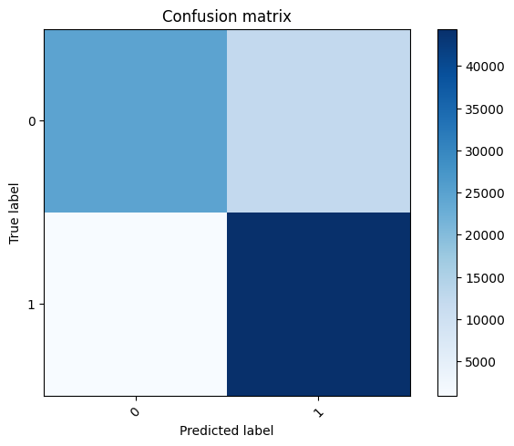

```
              precision    recall  f1-score   support

           0       0.96      0.67      0.79     36998
           1       0.78      0.98      0.87     45329

    accuracy                           0.84     82327
   macro avg       0.87      0.82      0.83     82327
weighted avg       0.86      0.84      0.83     82327
```

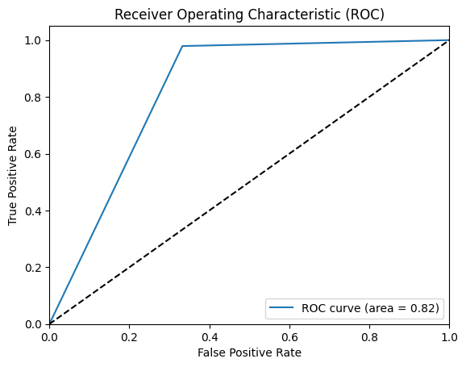

```python
# Define ModelCheckpoint outside the loop
checkpointer = ModelCheckpoint(filepath="dnn/best_weights.hdf5", verbose=0, save_best_only=True) # save best model

for i in range(5):
    print(i)

    # Build network
    model = Sequential()
    model.add(Dense(x_train.shape[1], input_dim=x_train.shape[1], activation='relu'))
    model.add(Dense(200, activation='relu'))
    model.add(Dense(100, activation='relu'))
    model.add(Dense(50, activation='relu'))
    model.add(Dense(25, activation='relu'))
    model.add(Dense(y_train.shape[1], activation='softmax'))
    model.compile(loss='categorical_crossentropy', optimizer='adam')

    monitor = EarlyStopping(monitor='val_loss', min_delta=1e-3, patience=5, verbose=1, mode='auto')

    model.fit(x_train,y_train,validation_data=(x_test,y_test),callbacks=[monitor,checkpointer],verbose=2,epochs=1000)


print('Training finished...Loading the best model')
print()
model.load_weights('dnn/best_weights.hdf5') # load weights from best model

# Measure accuracy
pred = model.predict(x_test)
pred = np.argmax(pred,axis=1)

y_true = np.argmax(y_test,axis=1)

# Compute confusion matrix
cm = confusion_matrix(y_true, pred)
print(cm)

print('Plotting confusion matrix')

plt.figure()
plot_confusion_matrix(cm, label)
plt.show()

print(classification_report(y_true, pred))

plot_roc(pred,y_true)
```

```
0
5479/5479 - 15s - loss: 0.1319 - val_loss: 0.2592 - 15s/epoch - 3ms/step
5479/5479 - 13s - loss: 0.1201 - val_loss: 0.2672 - 13s/epoch - 2ms/step
5479/5479 - 13s - loss: 0.1170 - val_loss: 0.2790 - 13s/epoch - 2ms/step
5479/5479 - 13s - loss: 0.1146 - val_loss: 0.2971 - 13s/epoch - 2ms/step
5479/5479 - 13s - loss: 0.1138 - val_loss: 0.3025 - 13s/epoch - 2ms/step
5479/5479 - 13s - loss: 0.1119 - val_loss: 0.3246 - 13s/epoch - 2ms/step
Epoch 6: early stopping
1
5479/5479 - 13s - loss: 0.1314 - val_loss: 0.3449 - 13s/epoch - 2ms/step
5479/5479 - 13s - loss: 0.1205 - val_loss: 0.2792 - 13s/epoch - 2ms/step
5479/5479 - 13s - loss: 0.1172 - val_loss: 0.3217 - 13s/epoch - 2ms/step
5479/5479 - 15s - loss: 0.1149 - val_loss: 0.2975 - 15s/epoch - 3ms/step
5479/5479 - 15s - loss: 0.1133 - val_loss: 0.3023 - 15s/epoch - 3ms/step
5479/5479 - 14s - loss: 0.1120 - val_loss: 0.2800 - 14s/epoch - 3ms/step
5479/5479 - 13s - loss: 0.1108 - val_loss: 0.2857 - 13s/epoch - 2ms/step
Epoch 7: early stopping
2
5479/5479 - 12s - loss: 0.1312 - val_loss: 0.2732 - 12s/epoch - 2ms/step
5479/5479 - 13s - loss: 0.1200 - val_loss: 0.3946 - 13s/epoch - 2ms/step
5479/5479 - 15s - loss: 0.1169 - val_loss: 0.2912 - 15s/epoch - 3ms/step
5479/5479 - 14s - loss: 0.1152 - val_loss: 0.2941 - 14s/epoch - 2ms/step
5479/5479 - 14s - loss: 0.1138 - val_loss: 0.2779 - 14s/epoch - 3ms/step
5479/5479 - 12s - loss: 0.1122 - val_loss: 0.3014 - 12s/epoch - 2ms/step
Epoch 6: early stopping
3
5479/5479 - 14s - loss: 0.1315 - val_loss: 0.3247 - 14s/epoch - 3ms/step
5479/5479 - 13s - loss: 0.1206 - val_loss: 0.3570 - 13s/epoch - 2ms/step
5479/5479 - 13s - loss: 0.1171 - val_loss: 0.2790 - 13s/epoch - 2ms/step
5479/5479 - 13s - loss: 0.1152 - val_loss: 0.3478 - 13s/epoch - 2ms/step
5479/5479 - 14s - loss: 0.1135 - val_loss: 0.2586 - 14s/epoch - 3ms/step
5479/5479 - 13s - loss: 0.1124 - val_loss: 0.3133 - 13s/epoch - 2ms/step
5479/5479 - 13s - loss: 0.1108 - val_loss: 0.2849 - 13s/epoch - 2ms/step
5479/5479 - 13s - loss: 0.1102 - val_loss: 0.3492 - 13s/epoch - 2ms/step
5479/5479 - 13s - loss: 0.1088 - val_loss: 0.2660 - 13s/epoch - 2ms/step
5479/5479 - 14s - loss: 0.1081 - val_loss: 0.2739 - 14s/epoch - 3ms/step
Epoch 10: early stopping
4
5479/5479 - 14s - loss: 0.1308 - val_loss: 0.3519 - 14s/epoch - 3ms/step
5479/5479 - 13s - loss: 0.1198 - val_loss: 0.2793 - 13s/epoch - 2ms/step
5479/5479 - 13s - loss: 0.1164 - val_loss: 0.3066 - 13s/epoch - 2ms/step
5479/5479 - 13s - loss: 0.1144 - val_loss: 0.2943 - 13s/epoch - 2ms/step
5479/5479 - 14s - loss: 0.1140 - val_loss: 0.2783 - 14s/epoch - 2ms/step
5479/5479 - 13s - loss: 0.1115 - val_loss: 0.2775 - 13s/epoch - 2ms/step
5479/5479 - 13s - loss: 0.1110 - val_loss: 0.2584 - 13s/epoch - 2ms/step
5479/5479 - 13s - loss: 0.1101 - val_loss: 0.3108 - 13s/epoch - 2ms/step
5479/5479 - 13s - loss: 0.1092 - val_loss: 0.2855 - 13s/epoch - 2ms/step
5479/5479 - 13s - loss: 0.1084 - val_loss: 0.3099 - 13s/epoch - 2ms/step
5479/5479 - 13s - loss: 0.1078 - val_loss: 0.3235 - 13s/epoch - 2ms/step
5479/5479 - 13s - loss: 0.1071 - val_loss: 0.3174 - 13s/epoch - 2ms/step
Epoch 12: early stopping
Training finished...Loading the best model

[[27642  9356]
 [ 1574 43755]]
Plotting confusion matrix
```

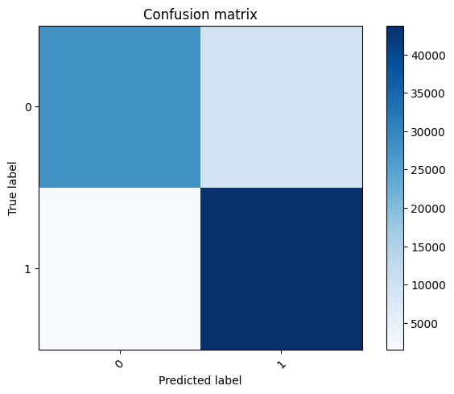

```
              precision    recall  f1-score   support

           0       0.95      0.75      0.83     36998
           1       0.82      0.97      0.89     45329

    accuracy                           0.87     82327
   macro avg       0.88      0.86      0.86     82327
weighted avg       0.88      0.87      0.86     82327
```

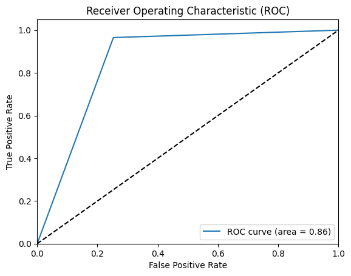

```python
# Define ModelCheckpoint outside the loop
checkpointer = ModelCheckpoint(filepath="dnn/best_weights.hdf5", verbose=0, save_best_only=True) # save best model

for i in range(5):
    print(i)

    # Build network
    model = Sequential()
    model.add(Dense(x_train.shape[1], input_dim=x_train.shape[1], activation='relu'))
    model.add(Dense(100, activation='relu'))
    model.add(Dense(50, activation='relu'))
    model.add(Dense(25, activation='relu'))
    model.add(Dense(y_train.shape[1], activation='softmax'))
    model.compile(loss='categorical_crossentropy', optimizer='adam')

    monitor = EarlyStopping(monitor='val_loss', min_delta=1e-3, patience=5, verbose=1, mode='auto')

    model.fit(x_train,y_train,validation_data=(x_test,y_test),callbacks=[monitor,checkpointer],verbose=2,epochs=1000)


print('Training finished...Loading the best model')
print()
model.load_weights('dnn/best_weights.hdf5') # load weights from best model

# Measure accuracy
pred = model.predict(x_test)
pred = np.argmax(pred,axis=1)

y_true = np.argmax(y_test,axis=1)

# Compute confusion matrix
cm = confusion_matrix(y_true, pred)
print(cm)

print('Plotting confusion matrix')

plt.figure()
plot_confusion_matrix(cm, label)
plt.show()

print(classification_report(y_true, pred))

plot_roc(pred,y_true)
```

```
0
5479/5479 - 14s - loss: 0.1314 - val_loss: 0.3244 - 14s/epoch - 2ms/step
5479/5479 - 13s - loss: 0.1200 - val_loss: 0.3392 - 13s/epoch - 2ms/step
5479/5479 - 13s - loss: 0.1170 - val_loss: 0.3129 - 13s/epoch - 2ms/step
5479/5479 - 13s - loss: 0.1149 - val_loss: 0.2782 - 13s/epoch - 2ms/step
5479/5479 - 13s - loss: 0.1133 - val_loss: 0.2760 - 13s/epoch - 2ms/step
5479/5479 - 13s - loss: 0.1118 - val_loss: 0.2921 - 13s/epoch - 2ms/step
5479/5479 - 14s - loss: 0.1111 - val_loss: 0.2807 - 14s/epoch - 2ms/step
5479/5479 - 16s - loss: 0.1105 - val_loss: 0.2876 - 16s/epoch - 3ms/step
5479/5479 - 16s - loss: 0.1095 - val_loss: 0.2528 - 16s/epoch - 3ms/step
5479/5479 - 16s - loss: 0.1088 - val_loss: 0.2863 - 16s/epoch - 3ms/step
5479/5479 - 14s - loss: 0.1082 - val_loss: 0.2648 - 14s/epoch - 3ms/step
5479/5479 - 15s - loss: 0.1076 - val_loss: 0.3112 - 15s/epoch - 3ms/step
5479/5479 - 15s - loss: 0.1070 - val_loss: 0.2725 - 15s/epoch - 3ms/step
5479/5479 - 15s - loss: 0.1062 - val_loss: 0.3340 - 15s/epoch - 3ms/step
Epoch 14: early stopping
1
5479/5479 - 15s - loss: 0.1330 - val_loss: 0.2896 - 15s/epoch - 3ms/step
5479/5479 - 14s - loss: 0.1207 - val_loss: 0.3353 - 14s/epoch - 3ms/step
5479/5479 - 13s - loss: 0.1171 - val_loss: 0.2841 - 13s/epoch - 2ms/step
5479/5479 - 15s - loss: 0.1150 - val_loss: 0.3364 - 15s/epoch - 3ms/step
5479/5479 - 15s - loss: 0.1135 - val_loss: 0.2975 - 15s/epoch - 3ms/step
5479/5479 - 15s - loss: 0.1123 - val_loss: 0.2972 - 15s/epoch - 3ms/step
5479/5479 - 15s - loss: 0.1111 - val_loss: 0.2713 - 15s/epoch - 3ms/step
5479/5479 - 15s - loss: 0.1101 - val_loss: 0.3217 - 15s/epoch - 3ms/step
5479/5479 - 14s - loss: 0.1097 - val_loss: 0.3110 - 14s/epoch - 3ms/step
5479/5479 - 14s - loss: 0.1087 - val_loss: 0.2831 - 14s/epoch - 3ms/step
5479/5479 - 15s - loss: 0.1082 - val_loss: 0.2844 - 15s/epoch - 3ms/step
5479/5479 - 14s - loss: 0.1079 - val_loss: 0.2931 - 14s/epoch - 3ms/step
Epoch 12: early stopping
2
5479/5479 - 15s - loss: 0.1313 - val_loss: 0.2780 - 15s/epoch - 3ms/step
5479/5479 - 15s - loss: 0.1203 - val_loss: 0.2848 - 15s/epoch - 3ms/step
5479/5479 - 13s - loss: 0.1171 - val_loss: 0.2657 - 13s/epoch - 2ms/step
5479/5479 - 13s - loss: 0.1149 - val_loss: 0.2978 - 13s/epoch - 2ms/step
5479/5479 - 13s - loss: 0.1137 - val_loss: 0.3150 - 13s/epoch - 2ms/step
5479/5479 - 13s - loss: 0.1124 - val_loss: 0.2758 - 13s/epoch - 2ms/step
5479/5479 - 13s - loss: 0.1110 - val_loss: 0.2698 - 13s/epoch - 2ms/step
5479/5479 - 13s - loss: 0.1100 - val_loss: 0.2836 - 13s/epoch - 2ms/step
Epoch 8: early stopping
```

[output cut: 12 more lines]

```
4
5479/5479 - 13s - loss: 0.1324 - val_loss: 0.2846 - 13s/epoch - 2ms/step
5479/5479 - 13s - loss: 0.1200 - val_loss: 0.2740 - 13s/epoch - 2ms/step
5479/5479 - 13s - loss: 0.1171 - val_loss: 0.2481 - 13s/epoch - 2ms/step
5479/5479 - 13s - loss: 0.1153 - val_loss: 0.2988 - 13s/epoch - 2ms/step
5479/5479 - 13s - loss: 0.1132 - val_loss: 0.2864 - 13s/epoch - 2ms/step
5479/5479 - 13s - loss: 0.1120 - val_loss: 0.2782 - 13s/epoch - 2ms/step
5479/5479 - 13s - loss: 0.1107 - val_loss: 0.2635 - 13s/epoch - 2ms/step
5479/5479 - 14s - loss: 0.1099 - val_loss: 0.3506 - 14s/epoch - 3ms/step
Epoch 8: early stopping
Training finished...Loading the best model

[[27639  9359]
 [ 2036 43293]]
Plotting confusion matrix
```

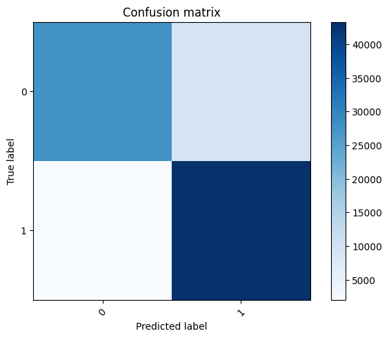

```
              precision    recall  f1-score   support

           0       0.93      0.75      0.83     36998
           1       0.82      0.96      0.88     45329

    accuracy                           0.86     82327
   macro avg       0.88      0.85      0.86     82327
weighted avg       0.87      0.86      0.86     82327
```

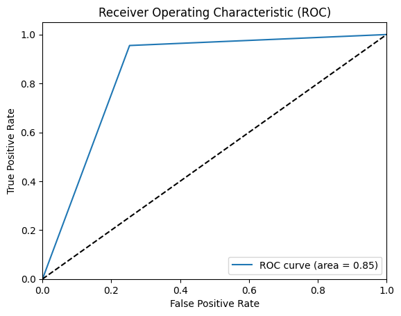

```python
# Define ModelCheckpoint outside the loop
checkpointer = ModelCheckpoint(filepath="dnn/best_weights.hdf5", verbose=0, save_best_only=True) # save best model

for i in range(5):
    print(i)

    # Build network
    model = Sequential()
    model.add(Dense(x_train.shape[1], input_dim=x_train.shape[1], activation='relu'))
    model.add(Dense(50, activation='relu'))
    model.add(Dense(25, activation='relu'))
    model.add(Dense(10, activation='relu'))
    model.add(Dense(y_train.shape[1], activation='softmax'))
    model.compile(loss='categorical_crossentropy', optimizer='adam')

    monitor = EarlyStopping(monitor='val_loss', min_delta=1e-3, patience=5, verbose=1, mode='auto')

    model.fit(x_train,y_train,validation_data=(x_test,y_test),callbacks=[monitor,checkpointer],verbose=2,epochs=1000)


print('Training finished...Loading the best model')
print()
model.load_weights('dnn/best_weights.hdf5') # load weights from best model

# Measure accuracy
pred = model.predict(x_test)
pred = np.argmax(pred,axis=1)

y_true = np.argmax(y_test,axis=1)

# Compute confusion matrix
cm = confusion_matrix(y_true, pred)
print(cm)

print('Plotting confusion matrix')

plt.figure()
plot_confusion_matrix(cm, label)
plt.show()

print(classification_report(y_true, pred))

plot_roc(pred,y_true)
```

#### Then Plot the accompanying Confusion Matrix and ROC curve for all models

### Activation: relu

### Optimizer: adam

```
0
5479/5479 - 15s - loss: 0.1307 - val_loss: 0.3438 - 15s/epoch - 3ms/step
5479/5479 - 14s - loss: 0.1194 - val_loss: 0.3597 - 14s/epoch - 3ms/step
5479/5479 - 13s - loss: 0.1169 - val_loss: 0.2498 - 13s/epoch - 2ms/step
5479/5479 - 13s - loss: 0.1149 - val_loss: 0.3041 - 13s/epoch - 2ms/step
5479/5479 - 13s - loss: 0.1127 - val_loss: 0.2649 - 13s/epoch - 2ms/step
5479/5479 - 12s - loss: 0.1116 - val_loss: 0.3429 - 12s/epoch - 2ms/step
5479/5479 - 12s - loss: 0.1106 - val_loss: 0.3087 - 12s/epoch - 2ms/step
5479/5479 - 12s - loss: 0.1094 - val_loss: 0.2923 - 12s/epoch - 2ms/step
Epoch 8: early stopping
1
5479/5479 - 12s - loss: 0.1308 - val_loss: 0.3670 - 12s/epoch - 2ms/step
5479/5479 - 13s - loss: 0.1206 - val_loss: 0.2641 - 13s/epoch - 2ms/step
5479/5479 - 13s - loss: 0.1171 - val_loss: 0.2857 - 13s/epoch - 2ms/step
5479/5479 - 13s - loss: 0.1151 - val_loss: 0.2950 - 13s/epoch - 2ms/step
5479/5479 - 13s - loss: 0.1139 - val_loss: 0.2824 - 13s/epoch - 2ms/step
5479/5479 - 13s - loss: 0.1122 - val_loss: 0.2939 - 13s/epoch - 2ms/step
5479/5479 - 13s - loss: 0.1111 - val_loss: 0.2763 - 13s/epoch - 2ms/step
Epoch 7: early stopping
2
5479/5479 - 13s - loss: 0.1318 - val_loss: 0.3589 - 13s/epoch - 2ms/step
5479/5479 - 12s - loss: 0.1200 - val_loss: 0.2996 - 12s/epoch - 2ms/step
5479/5479 - 14s - loss: 0.1166 - val_loss: 0.2993 - 14s/epoch - 2ms/step
5479/5479 - 13s - loss: 0.1140 - val_loss: 0.2746 - 13s/epoch - 2ms/step
5479/5479 - 13s - loss: 0.1129 - val_loss: 0.2861 - 13s/epoch - 2ms/step
5479/5479 - 14s - loss: 0.1117 - val_loss: 0.3433 - 14s/epoch - 3ms/step
5479/5479 - 13s - loss: 0.1107 - val_loss: 0.2647 - 13s/epoch - 2ms/step
5479/5479 - 13s - loss: 0.1097 - val_loss: 0.3013 - 13s/epoch - 2ms/step
5479/5479 - 15s - loss: 0.1087 - val_loss: 0.2516 - 15s/epoch - 3ms/step
5479/5479 - 15s - loss: 0.1094 - val_loss: 0.3211 - 15s/epoch - 3ms/step
5479/5479 - 15s - loss: 0.1074 - val_loss: 0.2721 - 15s/epoch - 3ms/step
5479/5479 - 15s - loss: 0.1065 - val_loss: 0.2770 - 15s/epoch - 3ms/step
5479/5479 - 14s - loss: 0.1065 - val_loss: 0.3833 - 14s/epoch - 3ms/step
5479/5479 - 14s - loss: 0.1059 - val_loss: 0.2964 - 14s/epoch - 3ms/step
Epoch 14: early stopping
3
5479/5479 - 15s - loss: 0.1318 - val_loss: 0.3246 - 15s/epoch - 3ms/step
5479/5479 - 15s - loss: 0.1200 - val_loss: 0.2961 - 15s/epoch - 3ms/step
5479/5479 - 14s - loss: 0.1172 - val_loss: 0.2607 - 14s/epoch - 3ms/step
5479/5479 - 14s - loss: 0.1152 - val_loss: 0.2630 - 14s/epoch - 3ms/step
5479/5479 - 14s - loss: 0.1132 - val_loss: 0.2910 - 14s/epoch - 3ms/step
5479/5479 - 15s - loss: 0.1124 - val_loss: 0.2632 - 15s/epoch - 3ms/step
5479/5479 - 15s - loss: 0.1109 - val_loss: 0.3045 - 15s/epoch - 3ms/step
5479/5479 - 15s - loss: 0.1105 - val_loss: 0.2728 - 15s/epoch - 3ms/step
Epoch 8: early stopping
4
5479/5479 - 15s - loss: 0.1305 - val_loss: 0.3310 - 15s/epoch - 3ms/step
5479/5479 - 14s - loss: 0.1198 - val_loss: 0.2654 - 14s/epoch - 3ms/step
5479/5479 - 14s - loss: 0.1166 - val_loss: 0.3246 - 14s/epoch - 3ms/step
5479/5479 - 15s - loss: 0.1145 - val_loss: 0.2754 - 15s/epoch - 3ms/step
5479/5479 - 15s - loss: 0.1130 - val_loss: 0.3111 - 15s/epoch - 3ms/step
5479/5479 - 14s - loss: 0.1118 - val_loss: 0.3057 - 14s/epoch - 3ms/step
5479/5479 - 14s - loss: 0.1109 - val_loss: 0.2776 - 14s/epoch - 3ms/step
Epoch 7: early stopping
Training finished...Loading the best model

[[25679 11319]
 [ 1071 44258]]
Plotting confusion matrix
```

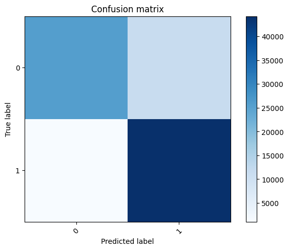

```
              precision    recall  f1-score   support

           0       0.96      0.69      0.81     36998
           1       0.80      0.98      0.88     45329

    accuracy                           0.85     82327
   macro avg       0.88      0.84      0.84     82327
weighted avg       0.87      0.85      0.85     82327
```

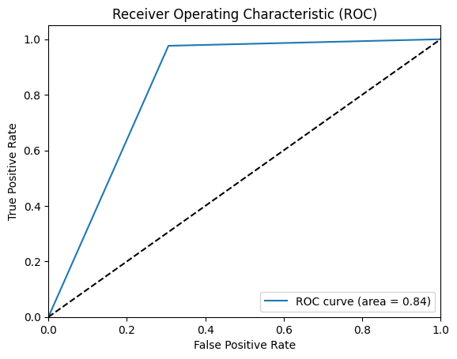

```python
# Define ModelCheckpoint outside the loop
checkpointer = ModelCheckpoint(filepath="dnn/best_weights.hdf5", verbose=0, save_best_only=True) # save best model

for i in range(5):
    print(i)

    # Build network
    model = Sequential()
    model.add(Dense(x_train.shape[1], input_dim=x_train.shape[1], activation='relu'))
    model.add(Dense(100, activation='relu'))
    model.add(Dense(50, activation='relu'))
    model.add(Dense(25, activation='relu'))
    model.add(Dense(y_train.shape[1], activation='softmax'))
    model.compile(loss='categorical_crossentropy', optimizer='adam')

    monitor = EarlyStopping(monitor='val_loss', min_delta=1e-3, patience=5, verbose=1, mode='auto')

    model.fit(x_train,y_train,validation_data=(x_test,y_test),callbacks=[monitor,checkpointer],verbose=2,epochs=1000)


print('Training finished...Loading the best model')
print()
model.load_weights('dnn/best_weights.hdf5') # load weights from best model

# Measure accuracy
pred = model.predict(x_test)
pred = np.argmax(pred,axis=1)

y_true = np.argmax(y_test,axis=1)

# Compute confusion matrix
cm = confusion_matrix(y_true, pred)
print(cm)

print('Plotting confusion matrix')

plt.figure()
plot_confusion_matrix(cm, label)
plt.show()

print(classification_report(y_true, pred))

plot_roc(pred,y_true)
```

### Activation: relu

### Optimizer: sgd

```
0
5479/5479 - 13s - loss: 0.1570 - val_loss: 0.3766 - 13s/epoch - 2ms/step
5479/5479 - 13s - loss: 0.1249 - val_loss: 0.3477 - 13s/epoch - 2ms/step
5479/5479 - 14s - loss: 0.1217 - val_loss: 0.3251 - 14s/epoch - 3ms/step
5479/5479 - 14s - loss: 0.1201 - val_loss: 0.3051 - 14s/epoch - 3ms/step
5479/5479 - 14s - loss: 0.1185 - val_loss: 0.3683 - 14s/epoch - 3ms/step
5479/5479 - 13s - loss: 0.1174 - val_loss: 0.3261 - 13s/epoch - 2ms/step
5479/5479 - 13s - loss: 0.1166 - val_loss: 0.3425 - 13s/epoch - 2ms/step
5479/5479 - 13s - loss: 0.1158 - val_loss: 0.3850 - 13s/epoch - 2ms/step
5479/5479 - 14s - loss: 0.1150 - val_loss: 0.3564 - 14s/epoch - 3ms/step
Epoch 9: early stopping
1
5479/5479 - 16s - loss: 0.1612 - val_loss: 0.3585 - 16s/epoch - 3ms/step
5479/5479 - 16s - loss: 0.1263 - val_loss: 0.3013 - 16s/epoch - 3ms/step
5479/5479 - 14s - loss: 0.1228 - val_loss: 0.2802 - 14s/epoch - 3ms/step
5479/5479 - 13s - loss: 0.1206 - val_loss: 0.3097 - 13s/epoch - 2ms/step
5479/5479 - 13s - loss: 0.1191 - val_loss: 0.3479 - 13s/epoch - 2ms/step
5479/5479 - 14s - loss: 0.1177 - val_loss: 0.3464 - 14s/epoch - 3ms/step
5479/5479 - 15s - loss: 0.1168 - val_loss: 0.3345 - 15s/epoch - 3ms/step
5479/5479 - 14s - loss: 0.1160 - val_loss: 0.3468 - 14s/epoch - 3ms/step
Epoch 8: early stopping
2
5479/5479 - 14s - loss: 0.1568 - val_loss: 0.3504 - 14s/epoch - 2ms/step
5479/5479 - 13s - loss: 0.1255 - val_loss: 0.3455 - 13s/epoch - 2ms/step
5479/5479 - 13s - loss: 0.1222 - val_loss: 0.3282 - 13s/epoch - 2ms/step
5479/5479 - 14s - loss: 0.1202 - val_loss: 0.3737 - 14s/epoch - 3ms/step
5479/5479 - 14s - loss: 0.1190 - val_loss: 0.2768 - 14s/epoch - 3ms/step
5479/5479 - 15s - loss: 0.1179 - val_loss: 0.3379 - 15s/epoch - 3ms/step
5479/5479 - 14s - loss: 0.1170 - val_loss: 0.2945 - 14s/epoch - 3ms/step
5479/5479 - 14s - loss: 0.1160 - val_loss: 0.3589 - 14s/epoch - 3ms/step
5479/5479 - 14s - loss: 0.1152 - val_loss: 0.3817 - 14s/epoch - 3ms/step
5479/5479 - 14s - loss: 0.1146 - val_loss: 0.3149 - 14s/epoch - 3ms/step
Epoch 10: early stopping
3
5479/5479 - 14s - loss: 0.1589 - val_loss: 0.3384 - 14s/epoch - 3ms/step
5479/5479 - 14s - loss: 0.1260 - val_loss: 0.2993 - 14s/epoch - 3ms/step
5479/5479 - 14s - loss: 0.1225 - val_loss: 0.3286 - 14s/epoch - 2ms/step
5479/5479 - 14s - loss: 0.1208 - val_loss: 0.2761 - 14s/epoch - 3ms/step
5479/5479 - 15s - loss: 0.1194 - val_loss: 0.3752 - 15s/epoch - 3ms/step
5479/5479 - 15s - loss: 0.1183 - val_loss: 0.2836 - 15s/epoch - 3ms/step
```

[output cut: 9 more lines]

```
5479/5479 - 13s - loss: 0.1262 - val_loss: 0.3593 - 13s/epoch - 2ms/step
5479/5479 - 13s - loss: 0.1229 - val_loss: 0.3882 - 13s/epoch - 2ms/step
5479/5479 - 14s - loss: 0.1203 - val_loss: 0.3070 - 14s/epoch - 2ms/step
5479/5479 - 14s - loss: 0.1188 - val_loss: 0.2781 - 14s/epoch - 3ms/step
5479/5479 - 14s - loss: 0.1174 - val_loss: 0.3141 - 14s/epoch - 3ms/step
5479/5479 - 14s - loss: 0.1165 - val_loss: 0.2875 - 14s/epoch - 2ms/step
5479/5479 - 13s - loss: 0.1156 - val_loss: 0.3174 - 13s/epoch - 2ms/step
5479/5479 - 14s - loss: 0.1149 - val_loss: 0.2775 - 14s/epoch - 3ms/step
5479/5479 - 14s - loss: 0.1140 - val_loss: 0.3015 - 14s/epoch - 3ms/step
Epoch 10: early stopping
Training finished...Loading the best model

[[25341 11657]
 [ 1162 44167]]
Plotting confusion matrix
```

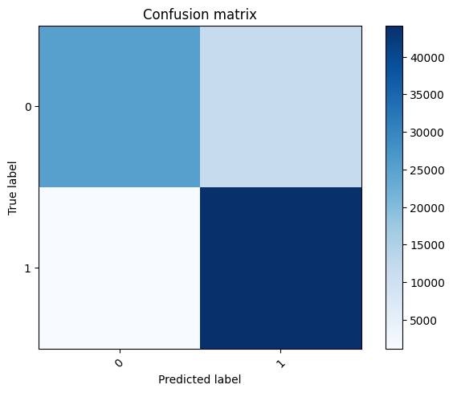

```
              precision    recall  f1-score   support

           0       0.96      0.68      0.80     36998
           1       0.79      0.97      0.87     45329

    accuracy                           0.84     82327
   macro avg       0.87      0.83      0.84     82327
weighted avg       0.87      0.84      0.84     82327
```

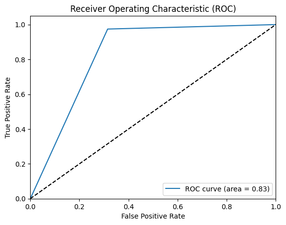

```python
# Define ModelCheckpoint outside the loop
checkpointer = ModelCheckpoint(filepath="dnn/best_weights.hdf5", verbose=0, save_best_only=True) # save best model

for i in range(5):
    print(i)

    # Build network
    model = Sequential()
    model.add(Dense(x_train.shape[1], input_dim=x_train.shape[1], activation='relu'))
    model.add(Dense(100, activation='relu'))
    model.add(Dense(50, activation='relu'))
    model.add(Dense(25, activation='relu'))
    model.add(Dense(y_train.shape[1], activation='softmax'))
    model.compile(loss='categorical_crossentropy', optimizer='sgd')

    monitor = EarlyStopping(monitor='val_loss', min_delta=1e-3, patience=5, verbose=1, mode='auto')

    model.fit(x_train,y_train,validation_data=(x_test,y_test),callbacks=[monitor,checkpointer],verbose=2,epochs=1000)


print('Training finished...Loading the best model')
print()
model.load_weights('dnn/best_weights.hdf5') # load weights from best model

# Measure accuracy
pred = model.predict(x_test)
pred = np.argmax(pred,axis=1)

y_true = np.argmax(y_test,axis=1)

# Compute confusion matrix
cm = confusion_matrix(y_true, pred)
print(cm)

print('Plotting confusion matrix')

plt.figure()
plot_confusion_matrix(cm, label)
plt.show()

print(classification_report(y_true, pred))

plot_roc(pred,y_true)
```

### Activation: sigmoid

### Optimizer: adam

```
0
5479/5479 - 15s - loss: 0.1612 - val_loss: 0.3207 - 15s/epoch - 3ms/step
5479/5479 - 15s - loss: 0.1290 - val_loss: 0.3906 - 15s/epoch - 3ms/step
5479/5479 - 15s - loss: 0.1247 - val_loss: 0.3404 - 15s/epoch - 3ms/step
5479/5479 - 15s - loss: 0.1227 - val_loss: 0.3013 - 15s/epoch - 3ms/step
5479/5479 - 15s - loss: 0.1209 - val_loss: 0.2786 - 15s/epoch - 3ms/step
5479/5479 - 14s - loss: 0.1197 - val_loss: 0.2602 - 14s/epoch - 3ms/step
5479/5479 - 14s - loss: 0.1186 - val_loss: 0.3640 - 14s/epoch - 3ms/step
5479/5479 - 15s - loss: 0.1176 - val_loss: 0.2927 - 15s/epoch - 3ms/step
5479/5479 - 13s - loss: 0.1164 - val_loss: 0.2633 - 13s/epoch - 2ms/step
5479/5479 - 13s - loss: 0.1152 - val_loss: 0.3162 - 13s/epoch - 2ms/step
5479/5479 - 13s - loss: 0.1143 - val_loss: 0.2631 - 13s/epoch - 2ms/step
Epoch 11: early stopping
1
5479/5479 - 13s - loss: 0.1631 - val_loss: 0.4434 - 13s/epoch - 2ms/step
5479/5479 - 13s - loss: 0.1283 - val_loss: 0.3829 - 13s/epoch - 2ms/step
5479/5479 - 13s - loss: 0.1241 - val_loss: 0.2924 - 13s/epoch - 2ms/step
5479/5479 - 13s - loss: 0.1217 - val_loss: 0.3155 - 13s/epoch - 2ms/step
5479/5479 - 13s - loss: 0.1202 - val_loss: 0.3333 - 13s/epoch - 2ms/step
5479/5479 - 13s - loss: 0.1188 - val_loss: 0.3120 - 13s/epoch - 2ms/step
5479/5479 - 13s - loss: 0.1181 - val_loss: 0.3369 - 13s/epoch - 2ms/step
5479/5479 - 14s - loss: 0.1169 - val_loss: 0.2717 - 14s/epoch - 2ms/step
5479/5479 - 13s - loss: 0.1160 - val_loss: 0.3310 - 13s/epoch - 2ms/step
5479/5479 - 13s - loss: 0.1153 - val_loss: 0.2664 - 13s/epoch - 2ms/step
5479/5479 - 14s - loss: 0.1141 - val_loss: 0.2586 - 14s/epoch - 2ms/step
5479/5479 - 15s - loss: 0.1133 - val_loss: 0.2814 - 15s/epoch - 3ms/step
5479/5479 - 15s - loss: 0.1126 - val_loss: 0.3141 - 15s/epoch - 3ms/step
5479/5479 - 14s - loss: 0.1119 - val_loss: 0.2800 - 14s/epoch - 3ms/step
5479/5479 - 12s - loss: 0.1113 - val_loss: 0.2596 - 12s/epoch - 2ms/step
5479/5479 - 13s - loss: 0.1106 - val_loss: 0.2898 - 13s/epoch - 2ms/step
Epoch 16: early stopping
2
5479/5479 - 13s - loss: 0.1701 - val_loss: 0.2889 - 13s/epoch - 2ms/step
5479/5479 - 13s - loss: 0.1280 - val_loss: 0.2929 - 13s/epoch - 2ms/step
5479/5479 - 13s - loss: 0.1242 - val_loss: 0.3171 - 13s/epoch - 2ms/step
5479/5479 - 13s - loss: 0.1218 - val_loss: 0.2498 - 13s/epoch - 2ms/step
5479/5479 - 13s - loss: 0.1205 - val_loss: 0.3331 - 13s/epoch - 2ms/step
5479/5479 - 13s - loss: 0.1191 - val_loss: 0.3332 - 13s/epoch - 2ms/step
5479/5479 - 13s - loss: 0.1181 - val_loss: 0.3291 - 13s/epoch - 2ms/step
5479/5479 - 15s - loss: 0.1170 - val_loss: 0.2777 - 15s/epoch - 3ms/step
```

[output cut: 14 more lines]

```
Epoch 11: early stopping
4
5479/5479 - 15s - loss: 0.1601 - val_loss: 0.4206 - 15s/epoch - 3ms/step
5479/5479 - 14s - loss: 0.1279 - val_loss: 0.2523 - 14s/epoch - 3ms/step
5479/5479 - 14s - loss: 0.1239 - val_loss: 0.2772 - 14s/epoch - 3ms/step
5479/5479 - 13s - loss: 0.1218 - val_loss: 0.3459 - 13s/epoch - 2ms/step
5479/5479 - 13s - loss: 0.1206 - val_loss: 0.2991 - 13s/epoch - 2ms/step
5479/5479 - 13s - loss: 0.1190 - val_loss: 0.3214 - 13s/epoch - 2ms/step
5479/5479 - 13s - loss: 0.1182 - val_loss: 0.2844 - 13s/epoch - 2ms/step
Epoch 7: early stopping
Training finished...Loading the best model

[[24627 12371]
 [ 1081 44248]]
Plotting confusion matrix
```

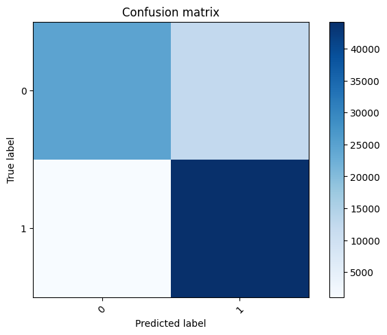

```
              precision    recall  f1-score   support

           0       0.96      0.67      0.79     36998
           1       0.78      0.98      0.87     45329

    accuracy                           0.84     82327
   macro avg       0.87      0.82      0.83     82327
weighted avg       0.86      0.84      0.83     82327
```

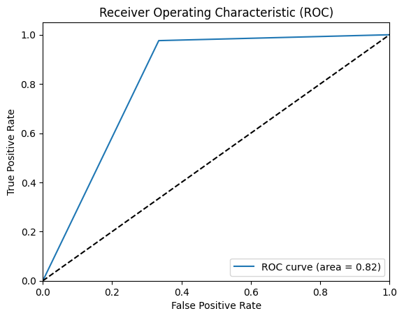

```python
# Define ModelCheckpoint outside the loop
checkpointer = ModelCheckpoint(filepath="dnn/best_weights.hdf5", verbose=0, save_best_only=True) # save best model

for i in range(5):
    print(i)

    # Build network
    model = Sequential()
    model.add(Dense(x_train.shape[1], input_dim=x_train.shape[1], activation='sigmoid'))
    model.add(Dense(100, activation='sigmoid'))
    model.add(Dense(50, activation='sigmoid'))
    model.add(Dense(25, activation='sigmoid'))
    model.add(Dense(y_train.shape[1], activation='softmax'))
    model.compile(loss='categorical_crossentropy', optimizer='adam')

    monitor = EarlyStopping(monitor='val_loss', min_delta=1e-3, patience=5, verbose=1, mode='auto')

    model.fit(x_train,y_train,validation_data=(x_test,y_test),callbacks=[monitor,checkpointer],verbose=2,epochs=1000)


print('Training finished...Loading the best model')
print()
model.load_weights('dnn/best_weights.hdf5') # load weights from best model

# Measure accuracy
pred = model.predict(x_test)
pred = np.argmax(pred,axis=1)

y_true = np.argmax(y_test,axis=1)

# Compute confusion matrix
cm = confusion_matrix(y_true, pred)
print(cm)

print('Plotting confusion matrix')

plt.figure()
plot_confusion_matrix(cm, label)
plt.show()

print(classification_report(y_true, pred))

plot_roc(pred,y_true)
```

### Activation: sigmoid

### Optimizer: sgd

```
0
5479/5479 - 13s - loss: 0.6211 - val_loss: 0.7149 - 13s/epoch - 2ms/step
5479/5479 - 13s - loss: 0.4755 - val_loss: 0.5854 - 13s/epoch - 2ms/step
5479/5479 - 12s - loss: 0.2530 - val_loss: 0.4817 - 12s/epoch - 2ms/step
5479/5479 - 13s - loss: 0.1912 - val_loss: 0.3566 - 13s/epoch - 2ms/step
5479/5479 - 13s - loss: 0.1682 - val_loss: 0.3374 - 13s/epoch - 2ms/step
5479/5479 - 13s - loss: 0.1582 - val_loss: 0.3611 - 13s/epoch - 2ms/step
5479/5479 - 14s - loss: 0.1521 - val_loss: 0.3279 - 14s/epoch - 3ms/step
5479/5479 - 14s - loss: 0.1484 - val_loss: 0.3397 - 14s/epoch - 3ms/step
5479/5479 - 14s - loss: 0.1455 - val_loss: 0.3002 - 14s/epoch - 3ms/step
5479/5479 - 14s - loss: 0.1429 - val_loss: 0.2738 - 14s/epoch - 3ms/step
5479/5479 - 14s - loss: 0.1416 - val_loss: 0.3446 - 14s/epoch - 3ms/step
5479/5479 - 14s - loss: 0.1399 - val_loss: 0.3862 - 14s/epoch - 2ms/step
5479/5479 - 14s - loss: 0.1387 - val_loss: 0.3281 - 14s/epoch - 2ms/step
5479/5479 - 14s - loss: 0.1373 - val_loss: 0.3502 - 14s/epoch - 3ms/step
5479/5479 - 14s - loss: 0.1368 - val_loss: 0.3432 - 14s/epoch - 3ms/step
Epoch 15: early stopping
1
5479/5479 - 15s - loss: 0.6241 - val_loss: 0.7087 - 15s/epoch - 3ms/step
5479/5479 - 14s - loss: 0.5551 - val_loss: 0.5791 - 14s/epoch - 3ms/step
5479/5479 - 15s - loss: 0.2907 - val_loss: 0.5322 - 15s/epoch - 3ms/step
5479/5479 - 15s - loss: 0.2116 - val_loss: 0.4928 - 15s/epoch - 3ms/step
5479/5479 - 14s - loss: 0.1767 - val_loss: 0.3924 - 14s/epoch - 3ms/step
5479/5479 - 13s - loss: 0.1634 - val_loss: 0.3368 - 13s/epoch - 2ms/step
5479/5479 - 13s - loss: 0.1556 - val_loss: 0.3161 - 13s/epoch - 2ms/step
5479/5479 - 13s - loss: 0.1505 - val_loss: 0.3181 - 13s/epoch - 2ms/step
5479/5479 - 14s - loss: 0.1469 - val_loss: 0.3634 - 14s/epoch - 3ms/step
5479/5479 - 14s - loss: 0.1443 - val_loss: 0.3905 - 14s/epoch - 3ms/step
5479/5479 - 13s - loss: 0.1423 - val_loss: 0.3517 - 13s/epoch - 2ms/step
5479/5479 - 13s - loss: 0.1408 - val_loss: 0.2833 - 13s/epoch - 2ms/step
5479/5479 - 13s - loss: 0.1395 - val_loss: 0.3561 - 13s/epoch - 2ms/step
5479/5479 - 12s - loss: 0.1383 - val_loss: 0.3317 - 12s/epoch - 2ms/step
5479/5479 - 12s - loss: 0.1374 - val_loss: 0.2989 - 12s/epoch - 2ms/step
5479/5479 - 13s - loss: 0.1366 - val_loss: 0.3183 - 13s/epoch - 2ms/step
5479/5479 - 15s - loss: 0.1358 - val_loss: 0.3107 - 15s/epoch - 3ms/step
Epoch 17: early stopping
2
5479/5479 - 13s - loss: 0.6214 - val_loss: 0.7237 - 13s/epoch - 2ms/step
5479/5479 - 12s - loss: 0.5000 - val_loss: 0.5762 - 12s/epoch - 2ms/step
5479/5479 - 12s - loss: 0.2632 - val_loss: 0.5137 - 12s/epoch - 2ms/step
```

[output cut: 34 more lines]

```
5479/5479 - 12s - loss: 0.1737 - val_loss: 0.3443 - 12s/epoch - 2ms/step
5479/5479 - 12s - loss: 0.1622 - val_loss: 0.3760 - 12s/epoch - 2ms/step
5479/5479 - 12s - loss: 0.1555 - val_loss: 0.3935 - 12s/epoch - 2ms/step
5479/5479 - 12s - loss: 0.1500 - val_loss: 0.3084 - 12s/epoch - 2ms/step
5479/5479 - 13s - loss: 0.1464 - val_loss: 0.3312 - 13s/epoch - 2ms/step
5479/5479 - 13s - loss: 0.1435 - val_loss: 0.3254 - 13s/epoch - 2ms/step
5479/5479 - 13s - loss: 0.1411 - val_loss: 0.3831 - 13s/epoch - 2ms/step
5479/5479 - 12s - loss: 0.1394 - val_loss: 0.3367 - 12s/epoch - 2ms/step
5479/5479 - 12s - loss: 0.1380 - val_loss: 0.3141 - 12s/epoch - 2ms/step
Epoch 13: early stopping
Training finished...Loading the best model

[[26041 10957]
 [ 2935 42394]]
Plotting confusion matrix
```

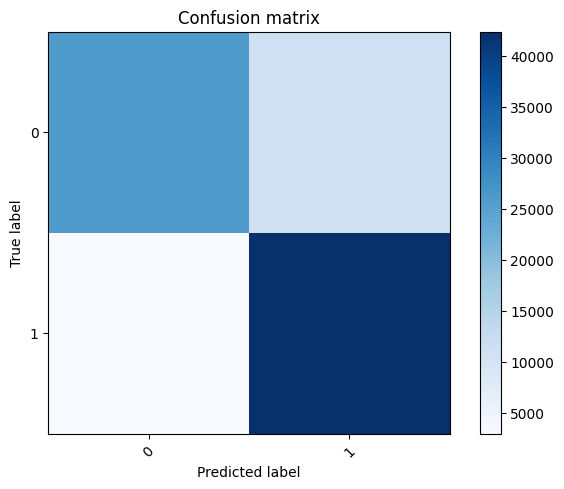

```
              precision    recall  f1-score   support

           0       0.90      0.70      0.79     36998
           1       0.79      0.94      0.86     45329

    accuracy                           0.83     82327
   macro avg       0.85      0.82      0.82     82327
weighted avg       0.84      0.83      0.83     82327
```

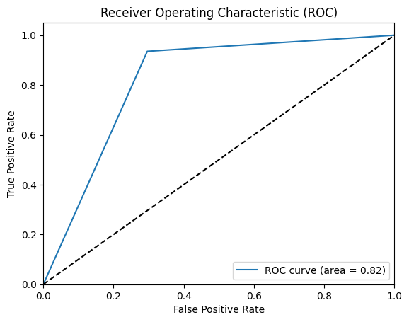

```python
# Define ModelCheckpoint outside the loop
checkpointer = ModelCheckpoint(filepath="dnn/best_weights.hdf5", verbose=0, save_best_only=True) # save best model

for i in range(5):
    print(i)

    # Build network
    model = Sequential()
    model.add(Dense(x_train.shape[1], input_dim=x_train.shape[1], activation='sigmoid'))
    model.add(Dense(100, activation='sigmoid'))
    model.add(Dense(50, activation='sigmoid'))
    model.add(Dense(25, activation='sigmoid'))
    model.add(Dense(y_train.shape[1], activation='softmax'))
    model.compile(loss='categorical_crossentropy', optimizer='sgd')

    monitor = EarlyStopping(monitor='val_loss', min_delta=1e-3, patience=5, verbose=1, mode='auto')

    model.fit(x_train,y_train,validation_data=(x_test,y_test),callbacks=[monitor,checkpointer],verbose=2,epochs=1000)


print('Training finished...Loading the best model')
print()
model.load_weights('dnn/best_weights.hdf5') # load weights from best model

# Measure accuracy
pred = model.predict(x_test)
pred = np.argmax(pred,axis=1)

y_true = np.argmax(y_test,axis=1)

# Compute confusion matrix
cm = confusion_matrix(y_true, pred)
print(cm)

print('Plotting confusion matrix')

plt.figure()
plot_confusion_matrix(cm, label)
plt.show()

print(classification_report(y_true, pred))

plot_roc(pred,y_true)
```